# Adherence to AAP Guidelines for Treatment Duration for Acute Otitis Media and Implications for Clinical Decision Support

Jonathan Beus, MD, MS

```r
# Note that this chunk can be changed to use sample data to demonstrate code.


# Use this for original data, containing PHI
knitr::opts_knit$set(root.dir = normalizePath('../Final_Project_PHI/01_raw_data'))

# Use this for simulated data to use with github post
# knitr::opts_knit$set(root.dir = normalizePath('./sample_data'))

# set this variable to TRUE to cache machine learning models so they are not executed everytime (i.e. while revising text, etc)
cache_models <- TRUE
```

```r
library(tidyverse)
library(ggplot2)
library(lubridate)
library(pROC)
library(knitr) # for table formatting
library(caret)
library(naivebayes) # implicitly used by caret
library(nnet) # implicitly used by caret for penalized multinomial regression
library(randomForest) # implicitly used by caret
library(xgboost)
library(doParallel)
library(multiROC) #used for multiclass roc
library(DMwR) # used for SMOTE resampling

theme_set(theme_bw())
```

#### Abbreviations Used

| Abbreviation |  |
| --- | --- |
| AAP | American Academy of Pediatrics |
| AOM | Acute Otitis Media |
| ASP | Antimicrobial Stewardship Program |
| CCC | Complex Chronic Condition |
| CDS | Clinical Decision Support |
| ED | Emergency Department |
| QI | Quality Improvement |

### Overview

[Jonathan Beus BMIN503 Final Project GitHub Repository](https://github.com/beusj/BMIN503_Final_Project)

This project examines adherence to treatment guidelines for antibiotic duration for [acute otitis media](https://www.healthychildren.org/English/health-issues/conditions/ear-nose-throat/Pages/Middle-Ear-Infections.aspx) (common ear infection) for patients seen and discharged from our emergency department. An American Academy of Pediatrics (AAP) guideline was published in 2013 with recommendations regarding treatment duration ([AAP Guidleline](https://pediatrics.aappublications.org/content/131/3/e964)) which was reflected in a local [Clinical Pathway](https://www.chop.edu/clinical-pathway/otitis-media-acute-clinical-pathway). Essentially, while 10 days of therapy has classicaly been used, for patients 2 years and older, 7 days of therapy is likely adequate. Our antimicrobial stewardship program (ASP) has asked that we consider implementing clinical decision support to encourage clinicians to follow these guidelines. In preparation for this, we would like to evaluate past rates of adherence to these guidelines and to identify patient and provider characteristics associated with adherence or non-adherence to these guidelines. This information will serve to define the magnitude of the problem and potentially highlight patient or provider populations for additional intervention.

To explore this question, we used an internal data warehouse, extracted from the Electronic Health Record. We wrote SQL queries to extract the pertinent information, identifying patients seen in our ED for Otitis Media from July 2011 through June 2019.

| Name | Title | Division/Department | Primary Discussion Points |
| --- | --- | --- | --- |
| Joe Zorc, MD, MSCE | Professor of Pediatrics, Director of Emergency Information Systems | Department of Emergency Medicine | We discussed which factors were most likely to be associated with adherence to the guidelines, including provider type (trainee, advanced practice provider, attending), calendar year, and use of the O… |
| Brandon Ku, MD | Associate Director for ED QI | Department of Emergency Medicine | We primarily discussed post-intervention assessment of the impact of a CDS-based QI intervention. Due to the rapid-cycle nature of improvement, we discussed using control charts for improvement monito… |
| Talene Metjian, PharmD | Manager, Antimicrobial Stewardship Program | Antimicrobial Stewardship Program | The majority of non-adherence occurs in patients >= 2 years as the shorter duration was a change from prior practice. The use of 10 days in patients < 2 years was and is the standard duration. As a re… |

### Introduction

#### Background and Significance

Antimicrobial resistance is a significant threat to modern healthcare. Antimicrobial resistance is developing more rapidly than new antimicrobials can be discovered. It is generally felt that antibiotic overuse is a major factor driving worsening resistance patterns. Antimicrobial stewardship is a field developed to help providers limit inappropriate antibiotic use. As discussed above, in 2013 an AAP policy guideline noted that, for patients >= 2 years, 7 days of antibiotic therapy was likely as effective as longer durations. The policy was well received, but probably more notable in that it provided guidance to providers about when *not* treating with antibiotics could be appropriate. The discussion about duration seems to have been overshadowed by the more surprising endorsement to not treat in specific cases. For many providers, when the decision was made to treat a patient with antibiotics, they continued to use 10 days of therapy.

When a patient diagnosed with AOM is discharged from our ED, there are several ways that an order for antibiotics can be placed. The provider could go to their “order tab” and enter the name of the antibiotic they would like to prescribe and, subsequently, the dosing and duration. This occurs some in the ED, but most ED providers have become accustomed to using a discharge Order Set. There is such an Order Set that currently exists for ear complaints. Historically, it has provided a list of antibiotics for providers to choose from (in addition to the ability to add a discharge diagnosis, instructions, etc). The antibiotic group is shared with Order Sets for other kinds of problems that might present to the ED (e.g. pneumonia) and has historically been defaulted to 10 days. This has made ordering 10 days of antibiotics the easiest thing to do. While outside the scope of the current report, we are implementing some features in the Order Set to help providers choose an appropriate antibiotic and also to guide them to the recommended duration based on age.

The goal of the current analysis and report is preparatory to CDS interventions and assessment of their effectiveness. As discussed above, we are interested in patient and provider factors that influence the selection of antibiotic duration.

#### Interdisciplinary Approach

For this project, we have primarily gathered resources with expertise in Clinical Informatics, Antimicrobial Stewardship (pharmacy), and Quality Improvement. Clinical informatics generally includes clinicians and draws from disciplines including human-computer interaction, decision science, analytics, and computer science. Clinical informatics is a burgeoning field and includes broad definitions, although here, we will generally consider its primary intent to be to help clinicians and patients by supporting quality, timely, efficient, and safe care through the use of information technology. While a software engineer might easily be able to add antibiotics and durations to an Order Set, a clinical informaticist gathers additional information from providers and/or their own clinical experience to think about the workflow by which a process is performed to improve the likelihood that the anticipated goal will be achieved in a way that supports, rather than disrupts, the provider’s clinical activities. The clinical informaticists involved (JZ and JB) have extensively discussed which dependent-variables are reasonably extracted from our data warehouse and might be informative in targeting CDS.

Our ASP pharmacist (TM) has been crucial to help define which clinical actions are desired and to incoporate the appropriate antibiotics as well as durations for appropriate patients. Our ASP pharmacist and QI expert (BK) have been instrumental in confirming the decision to focus our analysis on patients >= 2 years and to exclude patients prescribed azithromycin. Azithromycin is not a preferred antibiotic for the treatment of AOM, but is sometimes used in patients with severe allergies to the preferred agents. Unlike other antibiotics used to treat AOM, the duration of azithromycin is dependent on the dose used, not associated with age, and typically just 3 to 5 days. As a result, for patients treated with azithromycin, the prescription would almost always be adherent to the guideline to use 7 days of therapy. Its inclusion would thus artificially inflate the estimate of adherence to the prescribing recommendations.

### Methods

The data is derived from an institutional data warehouse. JB wrote SQL queries to extract the data from the data warehouse. We included data for patients seen in the ED between July 1, 2011 and June 30, 2019. Patients were included if:

1. They were discharged from the ED (not admitted to an inpatient unit)
2. Had a diagnosis (visit diagnosis entered by provider or coded diagnosis for billing) matching ‘otitis’, but not ‘externa’
3. Were less than 21 years at the time of arrival to the ED

The primary analysis shown below depends on a patient having received an antibiotic prescription. The data warehouse provides a unique key for visits, which was used to identify antibiotic prescriptions for patients in the cohort. We did not include antibiotics administered in the ED, only outpatient prescriptions. We primarily identified antibiotics using standardized classifications from the EHR. Identification of a standard antibiotic name was preformed in the database queries. The name can be derived from various fields, none of which are completely reliable (some are missing). The names or descriptions tend to include descriptions of the concentrations and/or the salt of the molecule. A series of regular expressions was used to extract the “base” or generic name such as “amoxicllin”).

In general, we use descriptive statistics to examine variables associated with adherence to the recommendations. These variables were chosen based on clinical expertise and suspected to impact adherence to the guidelines. In addition to descriptive statistics, we additionally used logistic regression to examine the contribution of each variable when accounting for the others. Where appropriate, chi-square and Fisher’s exact tests are used to compare proprotions across groups. Logistic regression is used to exam the relationship between guideline adherence and continuous variables (i.e. age). As described in the section regarding antibiotic prediction, several machine learning models were used.

#### Read in Data

```r
# Path to PHI data
read_path <- normalizePath('./') # used in the past to change path, now controlled by root directory, above


# Read Data
cohort <- read_csv(paste0(read_path, '/cohort.csv'))

ccc <- read_csv(paste0(read_path, '/ccc.csv'))

race <- read_csv(paste0(read_path, '/race.csv'))

meds <- read_csv(paste0(read_path, '/meds.csv'))

# Used to associated provider type with medication order
prov_hx <- read_csv(paste0(read_path, '/prov_hx.csv'))

allergy <- read_csv(paste0(read_path, '/allergy.csv'))
```

#### Combine Cohort Tables

```r
# join overall cohort with race and ccc tables by visit key
cohort.cln <- cohort %>%
  # left_join(tx_team.cln, by = 'VISIT_KEY') %>%
  left_join(race, by = 'PAT_KEY') %>%
  left_join(ccc, by = 'PAT_KEY')
```

#### Clean Up Allergies

```r
# combine different ways that the same allergy might be documented; summarise at the patient level
# prior to processing, each patient will have a separate entry for each allergen
abx_all <- allergy %>%
  select(VISIT_KEY, ALRG_DESC) %>%
  filter(!is.na(ALRG_DESC)) %>%
  group_by(VISIT_KEY) %>%
  mutate(
    pcn_all = ifelse(str_detect(ALRG_DESC,pattern = regex('(cillin|augmentin|zosyn)',ignore_case = T)),1,0),
    azith_all = ifelse(str_detect(ALRG_DESC,pattern = regex('(azithro)',ignore_case = T)),1,0),
    cef_all = ifelse(str_detect(ALRG_DESC,pattern = regex('ce(f|ph)',ignore_case = T)),1,0),
  ) %>%
  mutate(
    pcn_all = max(pcn_all),
    azith_all = max(azith_all),
    cef_all = max(cef_all)
  ) %>%
  select(-ALRG_DESC) %>%
  arrange(VISIT_KEY) %>%
  filter(sum(pcn_all, azith_all, cef_all) > 0) %>%
  distinct()
```

#### Add Allergies to Cohort Data

```r
cohort.cln <- cohort.cln %>%
  left_join(abx_all, by = 'VISIT_KEY') %>%
  mutate_at(vars(pcn_all, azith_all, cef_all), function(x) ifelse(is.na(x), 0, x))
```

#### Join Provider Type to Medications

The provider type history is stored in a different database, so it is not possible to join in the initial query.

```r
meds.cln <- meds

# join to provider type at appropriate time (provider types can change as providers progress in training/etc)
prov_hx.meds <- meds.cln %>%
  select(MED_ORD_KEY, MED_ORD_CREATE_DT, PROV_ID) %>%
  left_join(prov_hx, by = 'PROV_ID') %>%
  filter(MED_ORD_CREATE_DT >= CONTACT_DATE, MED_ORD_CREATE_DT < EFF_TO_DATE) %>%
  select(MED_ORD_KEY, PROV_TYPE)

# prov_hx.meds %>%
#   summarise(n_distinct(MED_ORD_KEY))

meds.cln <- meds.cln %>%
  left_join(prov_hx.meds, by = 'MED_ORD_KEY')


# determined these classifications by manual review of provider names
meds.cln <- meds.cln %>%
  mutate(
    PROV_TYPE = ifelse(PROV_ID %in% c(18941,19355,8743), 'Resident', PROV_TYPE),
    PROV_TYPE = ifelse(PROV_ID %in% c(21864), 'Physician', PROV_TYPE)
         ) %>%
  select(-contains(('PROV_ID')))
```

#### Cohort Cleaning

Create variables from cohort data that will be used for exploration and modeling.

```r
cohort.cln <- cohort.cln %>%
  filter(AGE_AT_VISIT < 21) %>% # include only patients < 21 as we are interested in pediatric patients
  mutate(
         ACUITY = factor(ACUITY),
         sex_f = factor(SEX),
         arr_yr = year(ARRIVE_ED_DT), #extract year from date for grouping
         arr_mo = month(ARRIVE_ED_DT), #extract month from date
         fy_yr = ifelse(arr_mo < 7, arr_yr, arr_yr + 1), # extract fiscal year
         arr_yr_mo = floor_date(ARRIVE_ED_DT,'month'), # keep year-month
         arr_yr_qtr = floor_date(ARRIVE_ED_DT, unit = 'quarter'), # keep year-quarter
         arr_yr_wk = floor_date(ARRIVE_ED_DT, unit = 'week'),
  ) %>%
  mutate(
          age_ge_2 = ifelse(AGE_AT_VISIT >= 2, 1, 0), #binary age over 2 - this will be primary population
          age_ge_2 = factor(age_ge_2, levels = c('0', '1'), labels = c('Age < 2 yrs', 'Age >= 2 yrs')),
          age_f = cut(floor(AGE_AT_VISIT), breaks = c(0,6/12,1,2,5,12,Inf), labels = c('0-6 months','6-12 months','1-2 years','2-5 years','5-12 years','12+ years'), right = F), #splint into reasonable ages ranges based on clinical reasoning
          age_yr = floor(AGE_AT_VISIT) # essentially round age to first digit for use as continuous variable (little interest in more precision than this)
  ) %>%
  select(-AGE_AT_VISIT, -ARRIVE_ED_DT) %>% # don't need these anymore
  mutate(
      race_f = factor(RACE),
      ethn_f = factor(ETHNICITY)
  ) %>% # factor these for use in models
  select(-RACE, -ETHNICITY, SEX) %>%
  mutate(
    MED_COMPLEX_IND = factor(MED_COMPLEX_IND, levels = c(0,1), labels = c('No CCC','CCC Present'))
  )
```

#### Extract Dates Important to Medications

```r
meds.cln <- meds.cln %>%
  mutate(med_yr = year(MED_ORD_CREATE_DT),
         med_mo = month(MED_ORD_CREATE_DT),
         med_hr = hour(MED_ORD_CREATE_DT),
         med_hr_cut = cut(med_hr,breaks = seq(0, 24, 3),right = F), # split time of med administration into 3 hour intervals
         med_dow = wday(MED_ORD_CREATE_DT, label = T),
         med_dow_fri_sat = ifelse(med_dow %in% c('Fri','Sat'), 1, 0)
         ) %>%
  mutate(abx_name = factor(GEN_NM_CLN_SUB)) %>%
  select(-GEN_NM_CLN_SUB)
```

#### Medication Order Cleaning

Here we only include outpatient prescriptions (not antibiotics administered in the emergency department). The data is a prefiltered in the SQL queries to contain only medications classified as “Anti-Infective Agents” (which is mutually exclusive of topical antimicrobial products). We also exclude anti-infective agents that are not Antibacterial.

```r
meds.cln.op <- meds.cln %>%
  filter(D_ORD_MODE == 'Outpatient') %>%
  filter(D_ORD_CLASS != 'Historical Med') %>%
  filter(!D_PHARM_CLASS %in% c('Antiviral','Anthelmintic','Antifungals','Antimalarial','Antimycobacterial agents'))
```

We need to align how dates/times are coded. DISCONT_DT is stored in UTC, while ARR_ED_DT is stored in local timezone, so we need to adjust DISCONT_DT in order to assess time to discontinuation of an order.

```r
meds.cln.op <- meds.cln.op %>%
  mutate(
        med_disc_dt = DISCONT_DT - hours(4),
        disc_min = time_length(med_disc_dt - MED_ORD_CREATE_DT, unit = 'minutes')
        ) %>%
  select(-DISCONT_DT) %>%
  mutate(
    ss_used_med = factor(MED_ORD_SS, levels = c(0, 1), labels = c('No Order Set','Used Order Set'))
  ) %>%
  select(-MED_ORD_SS)
```

If there are multiple antibiotic orders we include only the most recent one. Some medication discontinuations occur at follow-up visits with primary care doctors or ED re-visits. Others reflect a change to the plan of care. We look at the distribution of discontinuation times to select a cutoff which is likely to represent a balance between these two possibilities. Ultimately, we will need to review some patient charts to explore the cases were the order was discontinued after several hours.

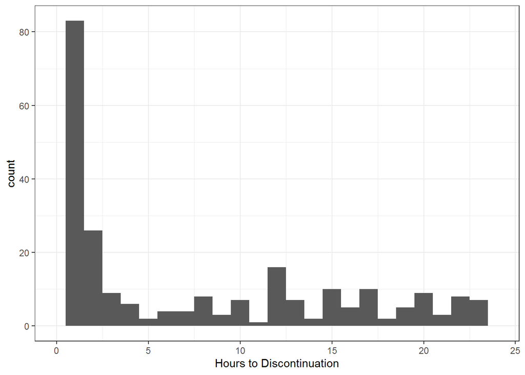

```r
meds.cln.op <- meds.cln.op %>%
  arrange(VISIT_KEY,med_disc_dt) %>%
  group_by(VISIT_KEY) %>%
  # group_by(VISIT_KEY,GEN_NM_CLN_SUB) %>%
  mutate(vk_abx_ct = n(),
         any_disc = ifelse(any(!is.na(med_disc_dt)),1,0), # any order discontinued
         all_disc = ifelse(all(!is.na(med_disc_dt)),1,0), # all orders discontinued
         ord_seq = row_number())

# majority of discontinuations happen in first 2-3 hours

# plot histogram of time to discontinuation
meds.cln.op %>%
  filter(all_disc == 1) %>%
  ggplot(aes(disc_min/60)) +
  geom_histogram(binwidth = 1) +
  xlim(0,24) +
  xlab('Hours to Discontinuation')
```

```r
nrow_pre <- nrow(meds.cln.op)

meds.cln.op <- meds.cln.op %>%
  ungroup() %>%
  filter(is.na(med_disc_dt) | disc_min >= 120) %>% # only keep if no discontinuation or discontinuation time >= 120 min
  filter(vk_abx_ct == ord_seq) # only include the most recent order

paste0('Rows Dropped: ',nrow_pre - nrow(meds.cln.op))
```

```
## [1] "Rows Dropped: 1624"
```

#### Medication Duration Cleanup

To assess guideline adhrenece, we need to know the duration for which the antibiotic was prescribed. The information is not recorded in an easily accessible discrete way.

```r
knitr::kable(table(meds.cln.op$FREQ_NM,useNA = 'always'), col.names = c('Frequency','Count'))
```

| Frequency | Count |
| --- | --- |
| 2 TIMES DAILY | 26111 |
| 3 TIMES DAILY | 1146 |
| 4 TIMES DAILY | 7 |
| DAILY | 936 |
| DEFAULT | 29 |
| EVERY 12 HOURS | 234 |
| EVERY 24 HOURS | 4 |
| EVERY 4 HOURS PRN | 1 |
| EVERY 6 HOURS | 13 |
| EVERY 8 HOURS | 25 |
| ONCE | 20 |
| NA | 0 |

```r
# Use ordered frequency from a discrete field to determine number of doses per day
times_daily <- meds.cln.op %>%
  filter(FREQ_NM != 'EVERY 4 HOURS PRN') %>%
  mutate(daily_or_once = ifelse(FREQ_NM %in% c("DAILY","ONCE"),1,0),
         times_daily = as.numeric(str_extract(FREQ_NM,regex('\\b\\d(?=( times daily))',ignore_case = T))),
         every_x_hrs = as.numeric(str_extract(FREQ_NM,regex('(?<=every )\\d{1,2}(?= hours)',ignore_case = T)))) %>%
  mutate(times_daily = ifelse(is.na(times_daily) & daily_or_once == 1, 1, times_daily),
        times_daily = ifelse(is.na(times_daily) & !is.na(every_x_hrs),(24/every_x_hrs),times_daily)) %>%
    group_by(FREQ_NM,daily_or_once,times_daily,every_x_hrs) %>%
    summarise(n())

# create lookup table for frequency
times_daily <- times_daily %>%
  group_by(FREQ_NM, times_daily) %>%
  select(FREQ_NM,times_daily)

# combine with lookup table
meds.cln.op <- meds.cln.op %>%
  left_join(times_daily, by='FREQ_NM')
```

The “SIG” is the historically hand-written and now, free-text part of the medication prescription indicating the instructions for the patient. The prescription duration is not available as a discrete field in our database, so we need to do some cleaning work to extract it from the text. When the duration is not explicitly stated in the text, we also have information about the total volume that was prescribed. We can use this data along with the frequency and dose to estimate the prescribed duration.

```r
set.seed(1234) # for sample to display below

# show examples of SIGs that we will be cleaning
meds.cln.op %>%
  group_by(abx_name) %>%
  mutate(abx_wt = 1/n()) %>%
  ungroup() %>%
  sample_n(size = 10, weight = abx_wt) %>%
  select(Antibiotic = abx_name, SIG) %>%
  kable()
```

| Antibiotic | SIG |
| --- | --- |
| Erythromycin | Take 1 tablet(s) (500 mg total) by mouth 3 times daily for 3 days. |
| Cephalexin | Take 7.6 mL (380 mg total) by mouth 3 times daily for 7 days. |
| Cephalexin | Take 6 mL (300 mg total) by mouth 4 times daily for 10 days. |
| Cephalexin | Take 8 mL (400 mg total) by mouth every 6 hours for 10 days. |
| Cefdinir | Take 1.5 mL (75 mg total) by mouth 2 times daily for 10 days. |
| Cephalexin | Take ONE capsule(s) (500 mg total) by mouth 3 times daily for 10 days. |
| Penicillin V | Take 10 mL (250 mg total) by mouth every 8 hours for 10 days. |
| Levofloxacin | Take 12 mL (300 mg total) by mouth once a day for 7 days. |
| Clindamycin | Take 8.9 mL (133.5 mg total) by mouth 3 times daily for 10 days. |
| Cefuroxime | Take 3.8 mL (190 mg total) by mouth every 12 hours. |

```r
# regex pattern used in one of the cleaning steps below
patt <- paste0('\\b(for|X)\\s+(the|next|\\s+)*(\\d+|','four|',')\\s+(more\\s+)?(day(s)?|dose(s)?)\\b')

# Parse sig, primarily using regular expressions
tmp <- meds.cln.op %>%
  select(MED_ORD_KEY, abx_name, FREQ_NM, SIG, times_daily, MED_ORD_QTY, MED_ORD_QTY_VAL) %>%
  mutate(sig_ext_1st = str_extract(SIG,regex(patt,ignore_case = T)), #first pass gets at the majority of cases
         sig_num = str_extract(sig_ext_1st,regex('\\b\\d+\\b',ignore_case = T)), # number of doses or days
         sig_unit = str_extract(sig_ext_1st,regex('\\b(dose|day)(s)?\\b',ignore_case = T)), # doses versus days
         sig_then = str_extract(SIG,regex(paste0('\\b(?<=then)[\\w\\.\\s\\(\\)\\,]+',patt),ignore_case = T)), # case when there are two sets of instructions
         sig_then_form = str_extract(sig_then,regex(patt,ignore_case = T)),
         sig_then_num = str_extract(sig_then_form,regex('\\b\\d+|four\\b',ignore_case = T)),
         sig_then_num = ifelse(sig_then_num == 'four',4,sig_then_num),
         sig_then_unit = str_extract(sig_then_form,regex('\\b(dose|day)(s)?\\b',ignore_case = T)),
         ed_1st = str_extract(SIG,regex('\\b(1st|first)\\s+(dose)\\s+(given in ED)\\b',ignore_case = T))) %>%
  mutate(rx_days = ifelse(sig_unit %in% c('day','days') & sig_num != 1, sig_num,NA),
         rx_days = ifelse(sig_unit %in% c('dose','doses') & !is.na(times_daily) & is.na(rx_days),as.numeric(sig_num)/as.numeric(times_daily),rx_days),
         rx_days = ifelse(!is.na(sig_then_num) & abx_name != 'Azithromycin',as.numeric(sig_num) + as.numeric(sig_then_num), rx_days),
         rx_days = ifelse(!is.na(sig_then_num) & sig_num == 1, as.numeric(sig_num) + as.numeric(sig_then_num), rx_days),
         rx_days = ifelse(is.na(rx_days) & !is.na(sig_num),sig_num,rx_days),
         rx_days = ifelse(abx_name == 'Azithromycin' &  rx_days %in% c(2,4) & !is.na(ed_1st),as.numeric(rx_days) + 1, rx_days), #azithromycin tends to be 3 or 5 days
         rx_days = ifelse(is.na(rx_days) & !is.na(str_extract(SIG,regex('\\bday(s)?[\\s\\-\\#]+\\d+\\b',ignore_case = T))),5,rx_days), #capture remaining azithromycin 2-5 days
         rx_days = as.numeric(rx_days)
  ) %>% # sig dose extraction
  mutate(
    sig_dose = str_extract(SIG, regex('\\b[\\d\\.(TWO)]+\\s+(capsule\\(s\\)|tablet\\(s\\)|mL)+',ignore_case = T)),
    sig_dose = str_replace(sig_dose,'TWO','2'), # very specific to this data, in future could generalize if needed
    sig_dose_num = str_extract(sig_dose,regex('\\b[\\d\\.]+\\b',ignore_case = T)),
    ord_qty_num = str_extract(MED_ORD_QTY_VAL,regex('\\b[\\d\\.]+\\b',ignore_case = T)),
    ord_qty_unit = str_extract(MED_ORD_QTY_VAL,regex('(day|mL|bottle|capsule|tablet)',ignore_case = T)),
    fill_est_days = as.numeric(ifelse(ord_qty_unit == 'day', ord_qty_num, NA)),
    fill_est_days = (ifelse(is.na(fill_est_days) & ord_qty_unit %in% c('mL','capsule','tablet'), as.numeric(ord_qty_num)/(as.numeric(sig_dose_num)*as.numeric(times_daily)), fill_est_days)),
    fill_est_days = ifelse(MED_ORD_QTY_VAL == '30', 30/times_daily,fill_est_days), #edge case
    fill_est_days = ifelse(fill_est_days <= 1, NA, round(fill_est_days)),
    rx_days = ifelse(is.na(rx_days),fill_est_days,rx_days)
  )

set.seed(1234) # for sample to display below

# Show examples of duration extracted from sig
tmp %>%
  group_by(abx_name) %>%
  mutate(abx_wt = 1/n()) %>%
  ungroup() %>%
  sample_n(size = 10, weight = abx_wt) %>%
  select(Antibiotic = abx_name, Rx_Sig = SIG, Duration = rx_days) %>%
  kable()
```

| Antibiotic | Rx_Sig | Duration |
| --- | --- | --- |
| Erythromycin | Take 1 tablet(s) (500 mg total) by mouth 3 times daily for 3 days. | 3 |
| Cephalexin | Take 7.6 mL (380 mg total) by mouth 3 times daily for 7 days. | 7 |
| Cephalexin | Take 6 mL (300 mg total) by mouth 4 times daily for 10 days. | 10 |
| Cephalexin | Take 8 mL (400 mg total) by mouth every 6 hours for 10 days. | 10 |
| Cefdinir | Take 1.5 mL (75 mg total) by mouth 2 times daily for 10 days. | 10 |
| Cephalexin | Take ONE capsule(s) (500 mg total) by mouth 3 times daily for 10 days. | 10 |
| Penicillin V | Take 10 mL (250 mg total) by mouth every 8 hours for 10 days. | 10 |
| Levofloxacin | Take 12 mL (300 mg total) by mouth once a day for 7 days. | 7 |
| Clindamycin | Take 8.9 mL (133.5 mg total) by mouth 3 times daily for 10 days. | 10 |
| Cefuroxime | Take 3.8 mL (190 mg total) by mouth every 12 hours. | 11 |

```r
# when we look at examples where no duration was extracted, there are only a few cases where there is not enough information available to infer it (~ 8 cases)

# we also looked at additional subsets, such as unusual durations, and use of "doses" rather than "days", all of which yielded expected results.

# tmp %>%
#   filter(rx_days > 10)


# combine extracted duration back with medications table
meds.cln.op <- tmp %>%
  select(MED_ORD_KEY, rx_days) %>%
  left_join(meds.cln.op,by='MED_ORD_KEY') %>%
  select(VISIT_KEY, rx_days, abx_name, ss_used_med, PROV_TYPE, med_hr, med_hr_cut, med_dow) # drop variables that are no longer needed
```

```r
# Relabel provider types to clean them up
meds.cln.op <- meds.cln.op %>%
  mutate(
         prov_rx = ifelse(PROV_TYPE %in% c('Medical Student','Resident'), PROV_TYPE, NA),
         prov_rx = ifelse(PROV_TYPE %in% c('FELLOW','FELLOW-CRNA'), 'Fellow', prov_rx),
         prov_rx = ifelse(PROV_TYPE %in% c('Nurse Practitioner','Physician Assistant'), 'NP/PA', prov_rx),
         prov_rx = ifelse(PROV_TYPE %in% c('Physician', 'Physician with Sedation'), 'Attending', prov_rx),
         prov_rx = factor(prov_rx)
         ) %>%
  select(-PROV_TYPE)
```

#### Join medication to cohort data

```r
# all refers to the fact that no limits are being placed on the timing of the visit
meds.coh.all <- cohort.cln %>%
  left_join(meds.cln.op, by='VISIT_KEY') %>%
  filter(!is.na(rx_days)) %>%
  mutate( # create binary variable for adherence
         dur_compl = 0, # default not adherent
         dur_compl = ifelse(age_ge_2 == 'Age >= 2 yrs' & rx_days <= 7, 1, dur_compl), # if 2 or over, adherent if <= 7 days
         dur_compl = ifelse(age_ge_2 == 'Age < 2 yrs' & rx_days <= 10, 1, dur_compl), # if less than 2, adherent if <= 10 days
         dur_compl = ifelse(abx_name == 'Azithromycin' & rx_days <= 5, 1, dur_compl), # Azithromycin shouldn't be > 5 days, but we will exclude these later, anyway
         dur_compl = factor(dur_compl, levels = c('0','1'), labels = c( 'Prolonged Duration' , 'Guideline Followed'))
         ) %>%
  mutate(
    abx_name = factor(abx_name) # refactor to drop NAs in labels induced by joining to cohort
  ) %>%
  select(-VISIT_KEY, -PAT_KEY)

# for the majority of our analysis we only want visits that occurred through the end of FY 2019
meds.coh <- meds.coh.all %>%
  filter(arr_yr_mo >= '2011-07-01' & arr_yr_mo <= '2019-06-30')
```

After cleaning, there are 27155 unique visits. This indicates that 90% of ED patients had a matching antibiotic. On review of a sample (20) of cases without a match, either no antibiotic was prescribed or the patient received an antibiotic by injection in the ED.

Our primary focus will be on patients >= 2 years old, since this is the group in which the guidelines and our clinical pathway specify a different duration than has been standard. Additionally, we really only are interested in the most frequently used antibiotics. Finally, azithromcyin is not informative, since the duration is almost always 5 days, regardless of the indication (and is not addressed by the guidelines that are referenced).

```r
# primary cohort subset
coh.sub <- meds.coh %>%
    filter(age_yr >= 2)
```

We examine the frequency with which each antibiotic has been prescribed.

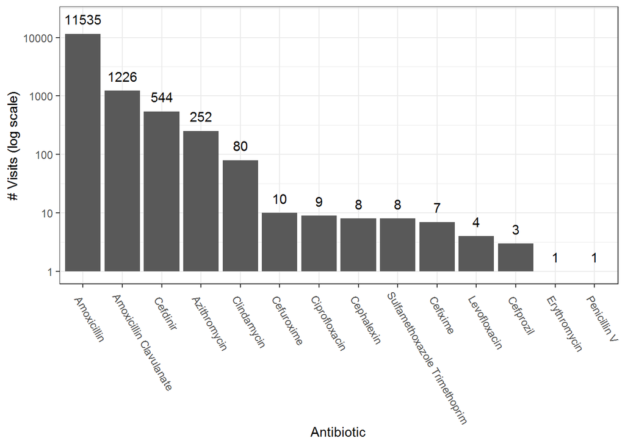

```r
coh.sub %>%
  group_by(abx_name) %>%
  summarise(n_visits = n()) %>%
  arrange(desc(n_visits)) %>%
  rename(Antibiotic = abx_name) %>%
  mutate(Antibiotic = fct_reorder(Antibiotic, n_visits, .desc = T)) %>%
  ggplot(aes(x = Antibiotic, y = n_visits)) +
  geom_col() +
  geom_text(aes(label=n_visits), nudge_y = .25) +
  scale_y_log10() +
  theme(axis.text.x = element_text(angle=-60, hjust = 0.05)) +
  ylab('# Visits (log scale)')
```

Based on review of the data, we will only include cases where the antibiotic was used with some reasonable frequency (> 10 times). This is somewhat arbitrary, although we don’t want to focus our efforts on rare cases. We will also exclude azithromycin.

```r
abx.inc <- coh.sub %>%
  group_by(abx_name) %>%
  summarise(n_visits = n()) %>%
  filter(n_visits > 10 & !(abx_name == 'Azithromycin')) %>%
  select(abx_name) %>%
  pull()

coh.sub <- coh.sub %>%
  filter(abx_name %in% abx.inc)
```

### Results

In this section, we summarise variables of interest in the cohort as defined above and present the results of the primary analysis.

Adherence to the guidelines was much lower in patients >= 2 years of age.

```r
# summarise data
tab <- meds.coh %>%
 group_by(
   age_ge_2, dur_compl
 ) %>%
  summarise(n = n()) %>%
  mutate(age_sum = sum(n),
         pct_compl = 100*n/age_sum)

# turn into a matrix and perform chi-square test
chi <- tab %>%
  select(-age_sum, - pct_compl) %>%
  pivot_wider(
    names_from = dur_compl,
    values_from = n,
    values_fill = list(n=0)
  ) %>%
  column_to_rownames(var = 'age_ge_2') %>%
  chisq.test(as.matrix())

# chi-square test
chi
```

```
##
##  Pearson's Chi-squared test with Yates' continuity correction
##
## data:  .
## X-squared = 20282, df = 1, p-value < 2.2e-16
```

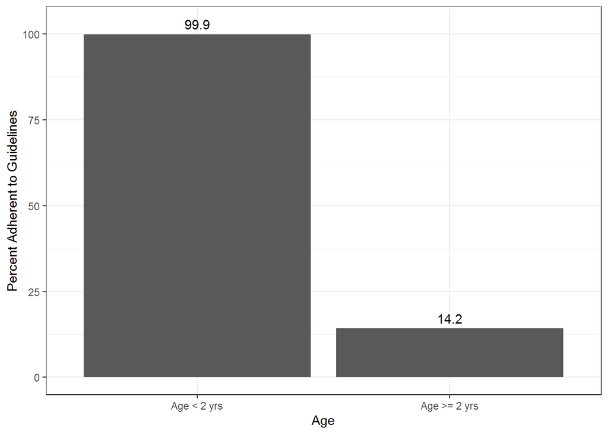

```r
tab %>%
  filter(dur_compl == 'Guideline Followed') %>%
  ggplot(aes(x = age_ge_2, y = pct_compl)) +
  geom_col(position = 'dodge') +
  geom_text(aes(y = pct_compl + 3, label = round(pct_compl, 1))) +
  xlab('Age') +
  ylab('Percent Adherent to Guidelines') +
  theme(legend.title = element_blank())
```

#### Demographics

Examine the distribution of ages - patients tend to be on the young side with an approximately exponential distribution.

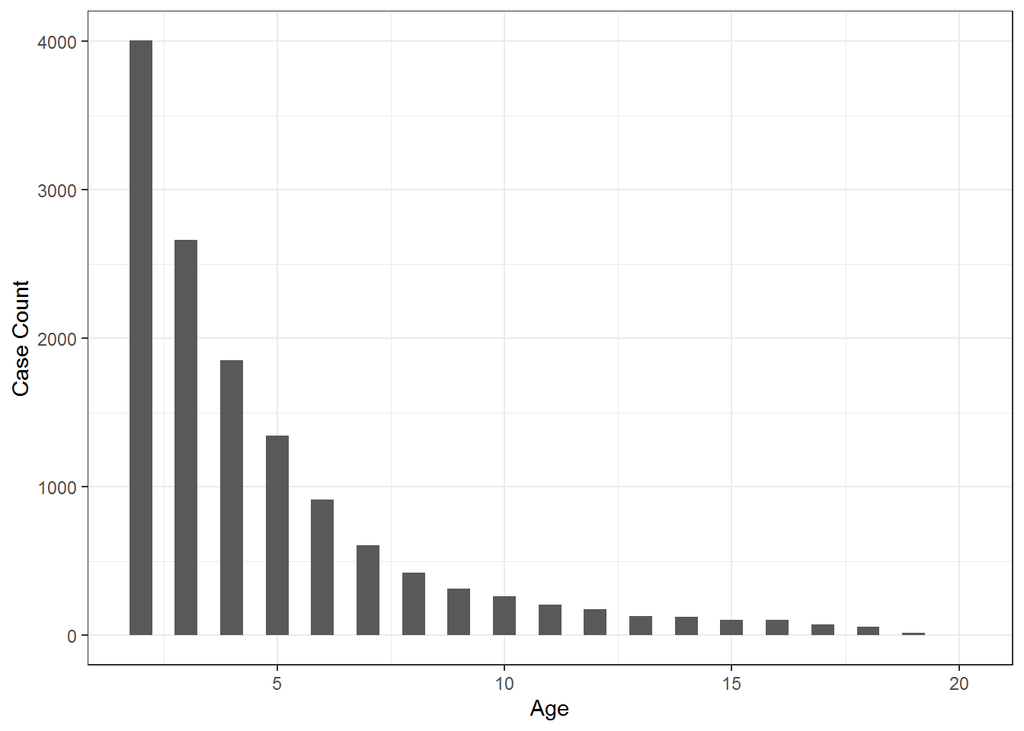

```r
coh.sub %>%
  ggplot(aes(age_yr)) +
  geom_histogram(binwidth = 0.5) +
  xlab('Age') +
  ylab('Case Count')
```

There are more males than females in the cohort.

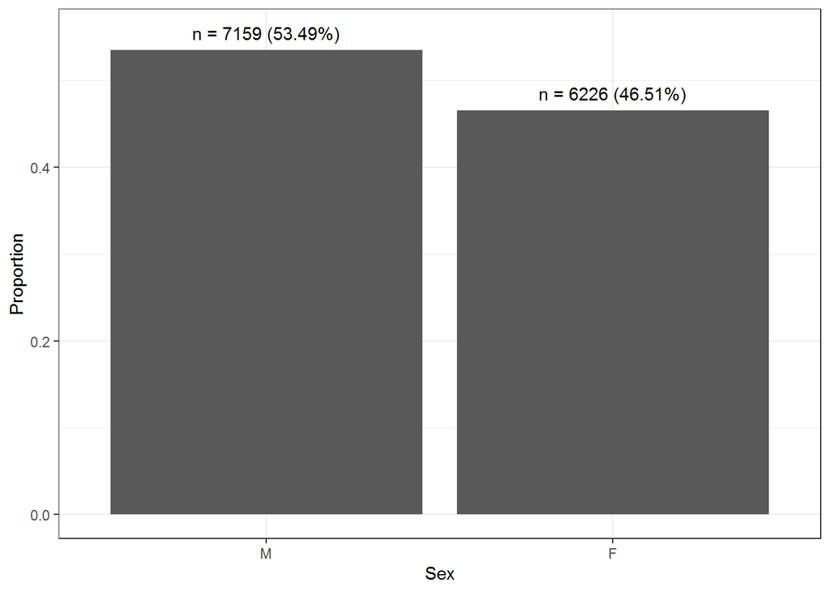

```r
coh.sub %>%
  mutate(var = SEX) %>%
  group_by(var) %>%
  summarise(n = n()) %>%
  mutate(sum = sum(n),
         prop = n/sum) %>%
  arrange(desc(n)) %>%
  mutate(var = fct_reorder(var, n, .desc = T)) %>%
  ggplot(aes(x = var, y = prop)) +
  geom_col() +
  geom_text(aes(label=paste0('n = ',n,' (',round(100*prop, 2),'%)')), nudge_y = .02) +
  # scale_y_log10() +
  theme(axis.text.x = element_text(angle=0)) +
  xlab('Sex') +
  ylab('Proportion')
```

The majority of patients are “Black or African American.”

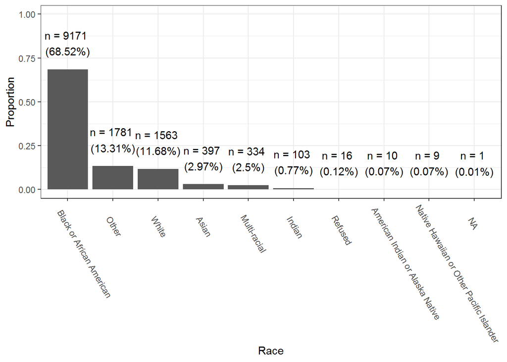

```r
coh.sub %>%
  mutate(var = race_f) %>%
  group_by(var) %>%
  summarise(n = n()) %>%
  mutate(sum = sum(n),
         prop = n/sum) %>%
  arrange(desc(n)) %>%
  mutate(var = fct_reorder(var, n, .desc = T)) %>%
  ggplot(aes(x = var, y = prop)) +
  geom_col() +
  geom_text(aes(angle = 0, label=paste0('n = ',n,' \n(',round(100*prop, 2),'%)')), nudge_y = .15) +
  # scale_y_log10() +
  theme(axis.text.x = element_text(angle=-60, hjust = 0.1)) +
  xlab('Race') +
  ylab('Proportion') +
  ylim(0,1)
```

There is some variation in volume from year to year.

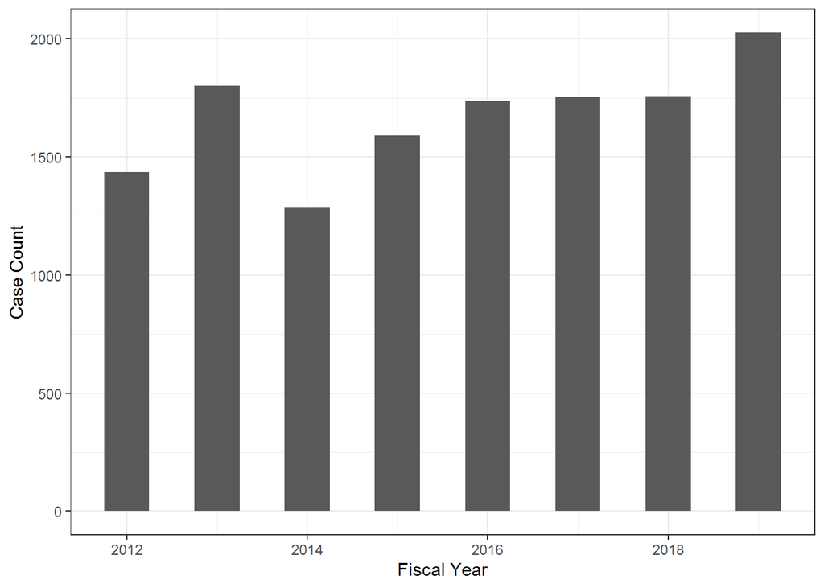

```r
coh.sub %>%
  ggplot(aes(fy_yr)) +
  geom_histogram(binwidth = 0.5) +
  xlab('Fiscal Year') +
  ylab('Case Count')
```

Only a small fraction of patients had a complex chronic condition (“CCC”). This feature is defined by a variety of diagnoses on a patient’s problem list or their dependence on technologic interventions (i.e. chronic need for ventilator).

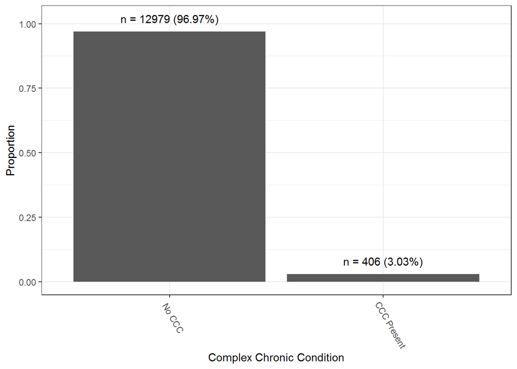

```r
coh.sub %>%
  mutate(var = MED_COMPLEX_IND) %>%
  group_by(var) %>%
  summarise(n = n()) %>%
  mutate(sum = sum(n),
         prop = n/sum) %>%
  arrange(desc(n)) %>%
  mutate(var = fct_reorder(var, n, .desc = T)) %>%
  ggplot(aes(x = var, y = prop)) +
  geom_col() +
  geom_text(aes(label=paste0('n = ',n,' (',round(100*prop, 2),'%)')), nudge_y = .05) +
  # scale_y_log10() +
  theme(axis.text.x = element_text(angle=-60, hjust = 0.1)) +
    xlab('Complex Chronic Condition') +
  ylab('Proportion')
```

#### Medication Attributes

Summary of antibiotics prescribed after filtering above. Amoxicillin represents a significant majority of cases.

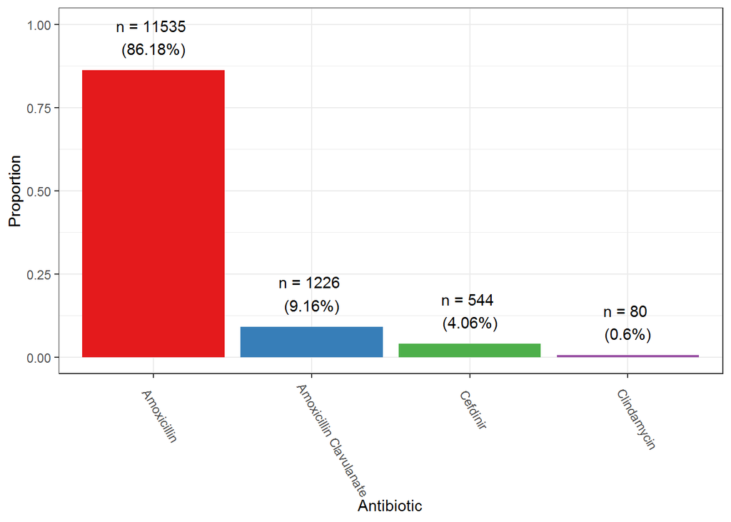

```r
coh.sub %>%
  mutate(var = abx_name) %>%
  group_by(var) %>%
  summarise(n = n()) %>%
  mutate(sum = sum(n),
         prop = n/sum) %>%
  arrange(desc(n)) %>%
  mutate(var = fct_reorder(var, n, .desc = T)) %>%
  ggplot(aes(x = var, y = prop)) +
  geom_col(aes(fill = var)) +
  geom_text(aes(label=paste0('n = ',n,' \n(',round(100*prop, 2),'%)')), nudge_y = .1) +
  # scale_y_log10() +
  theme(axis.text.x = element_text(angle=-60, hjust = 0.1)) +
  xlab('Antibiotic') +
  ylab('Proportion') +
  ylim(0,1) +
  scale_fill_brewer(type = 'qualitative', palette = 'Set1') +
  theme(legend.position = 'none')
```

A histogram of prescribed antibiotic duration provides more granular detail than the binary classifer of adherence to recommendations. The majority of prescriptions were written for 7 or 10 days with small numbers written for 5, 9, or 14 days.

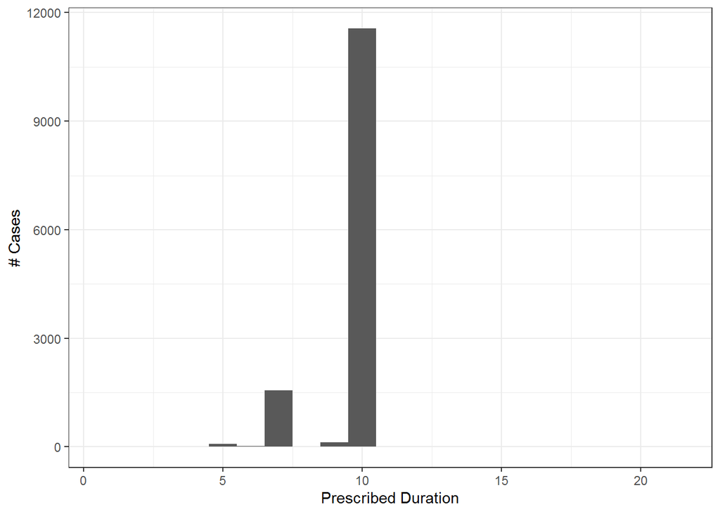

```r
coh.sub %>%
  ggplot(aes(x=rx_days)) +
  geom_histogram(binwidth = 1) +
  # scale_y_log10() +
  xlab('Prescribed Duration') +
  ylab('# Cases')
```

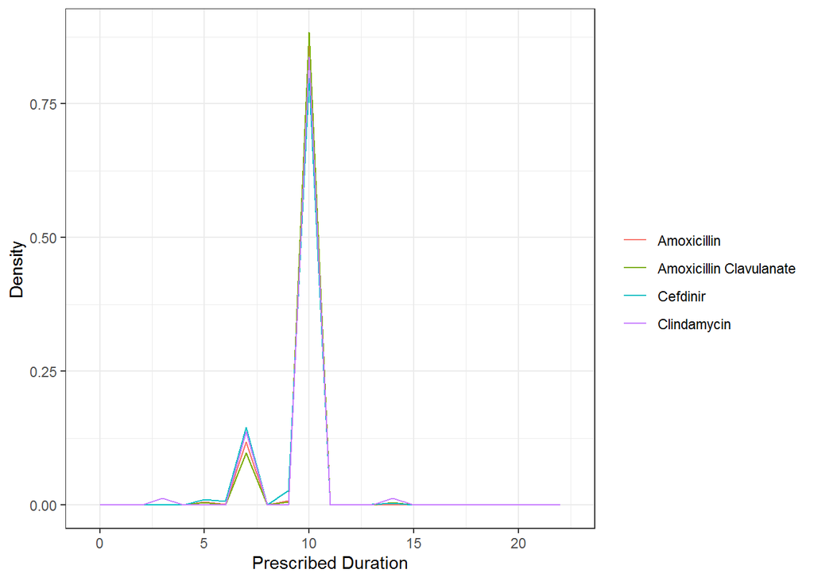

```r
# look at duration by antibiotic, use density so that we can compare across antibiotics
coh.sub %>%
  ggplot(aes(x=rx_days, stat(density), color = abx_name)) +
  geom_freqpoly(binwidth = 1) +
  # scale_y_log10() +
  xlab('Prescribed Duration') +
  ylab('Density') +
  scale_color_discrete('')
```

Antibiotic prescriptions were fairly evenly distributed throughout the week with slightly more prescriptions on weekends.

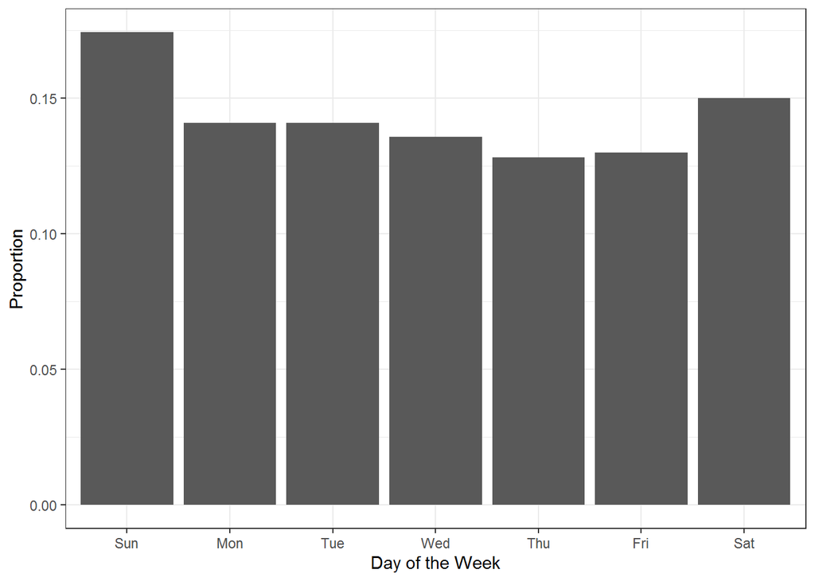

```r
coh.sub %>%
  group_by(med_dow) %>%
  summarise(n = n()) %>%
  mutate(
    sum = sum(n),
    prop =  n/sum
         ) %>%
  ggplot(aes(x=med_dow, y=prop)) +
  geom_col() +
  xlab('Day of the Week') +
  ylab('Proportion')
```

When we look at prescriptions by time of day, we see a pattern that generally resembles patient flow throughout the day. Volume is lowest in the early morning hours to mid-morning and busiest late in the evening.

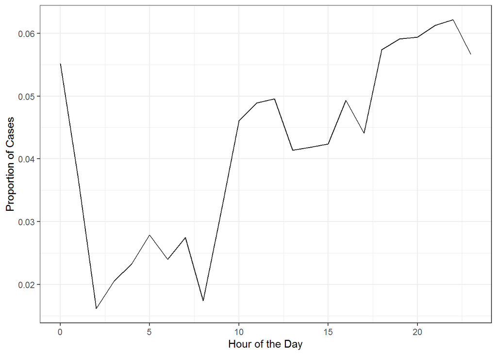

```r
coh.sub %>%
  group_by(med_hr) %>%
  summarise(n = n()) %>%
  mutate(
    sum = sum(n),
    prop =  n/sum
         ) %>%
  ggplot(aes(x=med_hr, y=prop)) +
  geom_line() +
  xlab('Hour of the Day') +
  ylab('Proportion of Cases')
```

The majority of prescriptions were written by attending providers (ED or Urgent care) with other significant proportions written by residents and advanced practice providers.

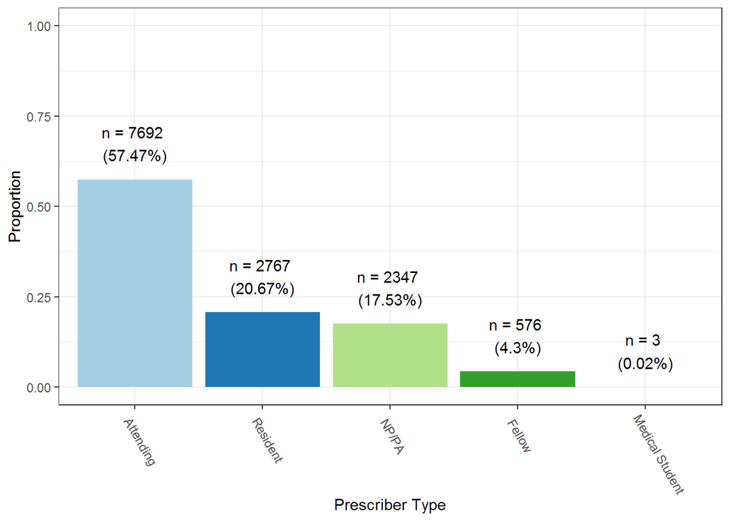

```r
coh.sub %>%
  mutate(var = prov_rx) %>%
  group_by(var) %>%
  summarise(n = n()) %>%
  mutate(sum = sum(n),
         prop = n/sum) %>%
  arrange(desc(n)) %>%
  mutate(var = fct_reorder(var, n, .desc = T)) %>%
  ggplot(aes(x = var, y = prop)) +
  geom_col(aes(fill=var)) +
  geom_text(aes(label=paste0('n = ',n,' \n(',round(100*prop, 2),'%)')), nudge_y = .1) +
  # scale_y_log10() +
  theme(axis.text.x = element_text(angle=-60, hjust = 0.1)) +
  xlab('Prescriber Type') +
  ylab('Proportion') +
  ylim(0,1) +
  scale_fill_brewer(type = 'qualitative', palette = 'Paired') +
  theme(legend.position = 'none')
```

The majority of antibiotic orders were placed using the Order Set, which supports targeting this method as an intervention to improve adherence. Still, nearly 15% of orders were placed outside of the Order Set.

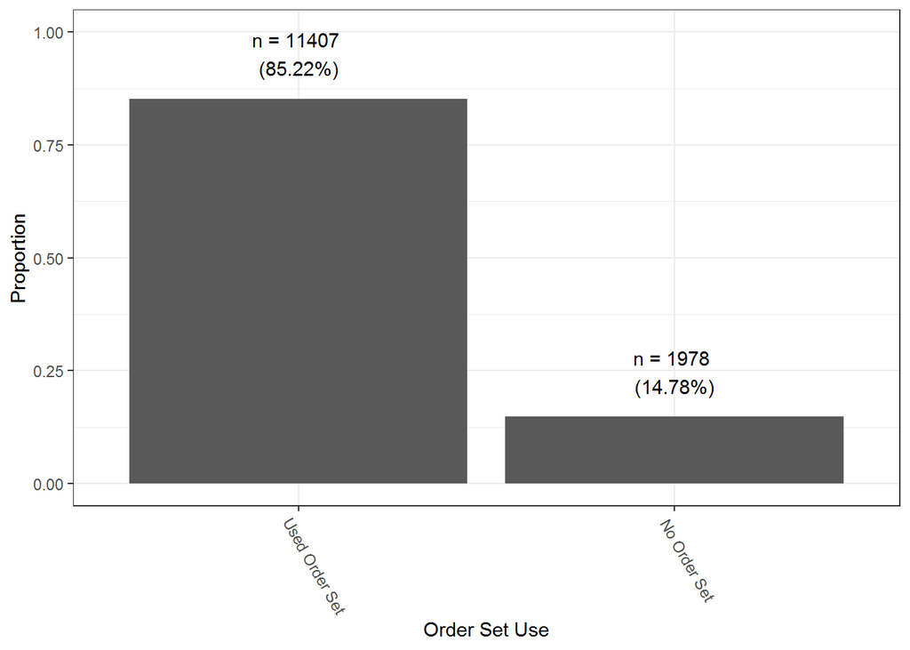

```r
coh.sub %>%
  mutate(var = ss_used_med) %>%
  group_by(var) %>%
  summarise(n = n()) %>%
  mutate(sum = sum(n),
         prop = n/sum) %>%
  arrange(desc(n)) %>%
  mutate(var = fct_reorder(var, n, .desc = T)) %>%
  ggplot(aes(x = var, y = prop)) +
  geom_col() +
  geom_text(aes(label=paste0('n = ',n,' \n(',round(100*prop, 2),'%)')), nudge_y = .1) +
  # scale_y_log10() +
  theme(axis.text.x = element_text(angle=-60, hjust = 0.1)) +
  xlab('Order Set Use') +
  ylab('Proportion') +
  ylim(0,1)
```

#### Explore Adherence to Recommendations by Covariates

The guideline was more more likely to be followed for older patients.

```r
# Logistic Regression with guideline adherence as the outcome and age as the model variable
f <- glm(dur_compl ~ age_yr, family=binomial, data=coh.sub)

broom::tidy(f, conf.int =T, exponentiate = T)
```

```
## # A tibble: 2 x 7
##   term        estimate std.error statistic  p.value conf.low conf.high
##   <chr>          <dbl>     <dbl>     <dbl>    <dbl>    <dbl>     <dbl>
## 1 (Intercept)   0.0967   0.0448      -52.2 0.         0.0886     0.106
## 2 age_yr        1.08     0.00676      11.7 1.20e-31   1.07       1.10
```

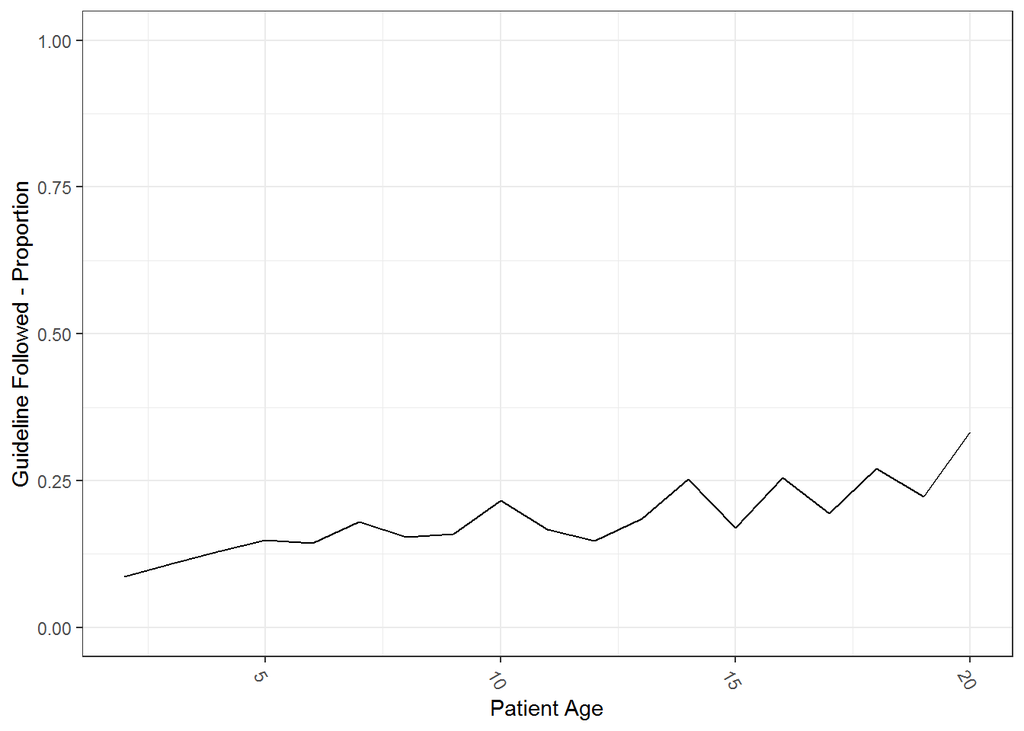

```r
# plot of adherence versus age
coh.sub %>%
  mutate(var = age_yr) %>%
  group_by(var, dur_compl) %>%
  summarise(n = n()) %>%
  mutate(sum = sum(n),
         prop = n/sum) %>%
  filter(dur_compl == 'Guideline Followed') %>%
  ggplot(aes(x = var, y = prop)) +
  # geom_smooth(method = 'glm', method.args = list(family = "binomial")) +
  geom_line() +
  theme(axis.text.x = element_text(angle=-60, hjust = 0.1)) +
  xlab('Patient Age') +
  ylab('Guideline Followed - Proportion') +
  ylim(0,1)
```

Sex does not appear to affect adherence to the guideline.

```r
tab <- coh.sub %>%
  mutate(var = SEX) %>%
  group_by(var, dur_compl) %>%
  summarise(n = n()) %>%
  mutate(sum = sum(n),
         prop = n/sum)

## in the future, could make this a function since repeat multiple times - more challenging due to non-standard evaluation with dplyr

# turn into a matrix
mat <- tab %>%
  select(-sum, -prop) %>%
  pivot_wider(
    names_from = dur_compl,
    values_from = n
  ) %>%
  column_to_rownames('var') %>%
  as.matrix()

# Fisher's Exact Test for guideline adherence versus sex
fisher.test(mat)
```

```
##
##  Fisher's Exact Test for Count Data
##
## data:  mat
## p-value = 0.9168
## alternative hypothesis: true odds ratio is not equal to 1
## 95 percent confidence interval:
##  0.8961901 1.1029440
## sample estimates:
## odds ratio
##  0.9941266
```

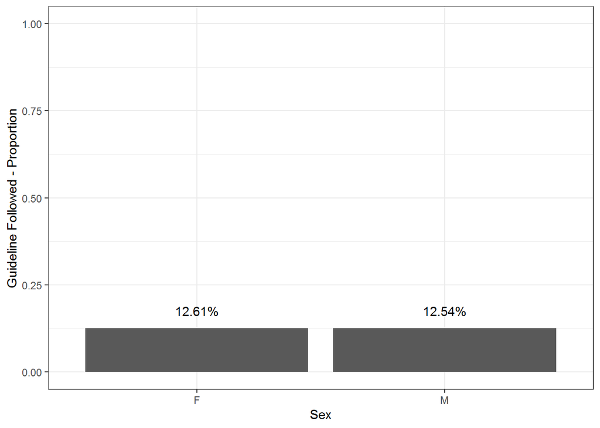

```r
tab %>%
  filter(dur_compl == 'Guideline Followed') %>%
  # arrange(desc(n)) %>%
  # ungroup() %>%
  # mutate(var = fct_reorder(var, n, .desc = T)) %>%
  ggplot(aes(x = var, y = prop)) +
  geom_col() +
  geom_text(aes(label=paste0(round(100*prop, 2),'%')), nudge_y = .05) +
  # scale_y_log10() +
  # theme(axis.text.x = element_text(angle=-60, hjust = 0.1)) +
  xlab('Sex') +
  ylab('Guideline Followed - Proportion') +
  ylim(0,1)
```

```r
  # scale_color_discrete('Adherence to Guidelines')
  # scale_fill_brewer(type = 'qualitative', palette = 'Paired') +
  # theme(legend.position = 'none')
```

Race has a small effect on guideline adherence, although many races are quite under-represented. When we look at the most frequent races from above (black, other, white), adherence to the guideline seemed to be quite similar.

```r
tab <- coh.sub %>%
  mutate(var = race_f) %>%
  group_by(var, dur_compl) %>%
  summarise(n = n()) %>%
  mutate(sum = sum(n),
         prop = n/sum)

# turn into a matrix
mat <- tab %>%
  select(-sum, -prop) %>%
  pivot_wider(
    names_from = dur_compl,
    values_from = n
  ) %>%
filter(!is.na(var)) %>%
column_to_rownames('var') %>%
  as.matrix()

# Fisher's Exact Test for guideline adherence versus race
fisher.test(mat, simulate.p.value = T)
```

```
##
##  Fisher's Exact Test for Count Data with simulated p-value (based on 2000 replicates)
##
## data:  mat
## p-value = 0.05697
## alternative hypothesis: two.sided
```

```r
# to assess by factor level - univariable logistic regression

fit <- glm(data = coh.sub %>%
          mutate(race_f = fct_relevel(race_f, 'Other'))
           , formula = dur_compl ~ race_f, family = binomial)
summary(fit)
```

```
##
## Call:
## glm(formula = dur_compl ~ race_f, family = binomial, data = coh.sub %>%
##     mutate(race_f = fct_relevel(race_f, "Other")))
##
## Deviance Residuals:
##     Min       1Q   Median       3Q      Max
## -0.9005  -0.5167  -0.5167  -0.5048   2.1460
##
## Coefficients:
##                                                  Estimate Std. Error z value Pr(>|z|)
## (Intercept)                                     -1.949122   0.071735 -27.171   <2e-16 ***
## race_fAmerican Indian or Alaska Native          -0.248102   1.056444  -0.235   0.8143
## race_fAsian                                      0.318375   0.153436   2.075   0.0380 *
## race_fBlack or African American                  0.002838   0.078378   0.036   0.9711
## race_fIndian                                     0.526014   0.259218   2.029   0.0424 *
## race_fMulti-racial                              -0.164452   0.190466  -0.863   0.3879
## race_fNative Hawaiian or Other Pacific Islander  1.255975   0.710736   1.767   0.0772 .
## race_fRefused                                    0.003212   0.759322   0.004   0.9966
## race_fWhite                                     -0.046705   0.105925  -0.441   0.6593
## ---
## Signif. codes:  0 '***' 0.001 '**' 0.01 '*' 0.05 '.' 0.1 ' ' 1
##
## (Dispersion parameter for binomial family taken to be 1)
##
##     Null deviance: 10120  on 13383  degrees of freedom
## Residual deviance: 10107  on 13375  degrees of freedom
##   (1 observation deleted due to missingness)
## AIC: 10125
##
## Number of Fisher Scoring iterations: 4
```

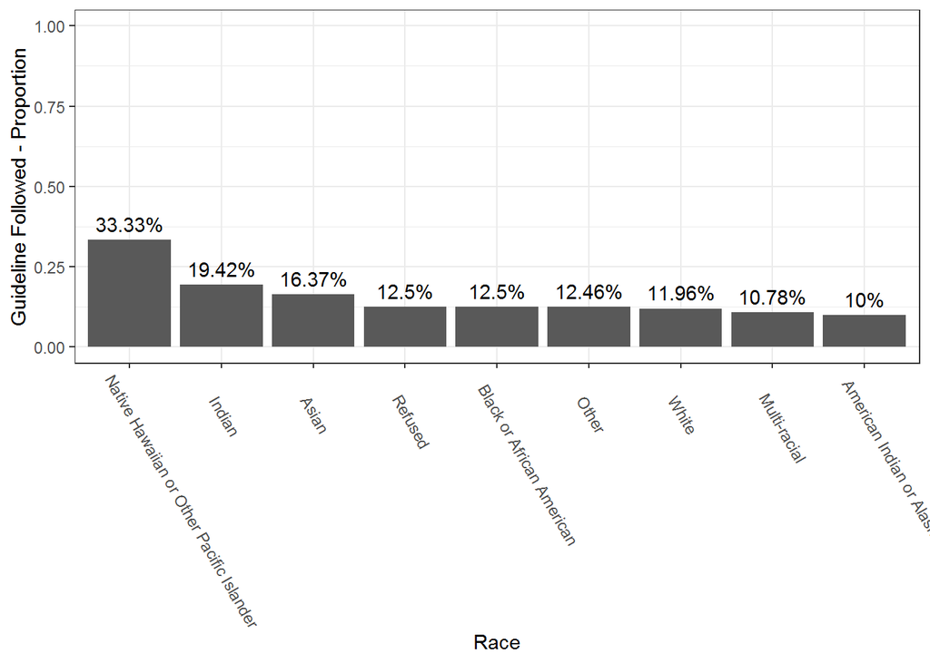

```r
tab %>%
  filter(dur_compl == 'Guideline Followed' & !is.na(var)) %>%
  arrange(desc(n)) %>%
  ungroup() %>%
  mutate(var = fct_reorder(var, prop, .desc = T)) %>%
  ggplot(aes(x = var, y = prop)) +
  geom_col() +
  geom_text(aes(label=paste0(round(100*prop, 2),'%')), nudge_y = .05) +
  # scale_y_log10() +
  theme(axis.text.x = element_text(angle=-60, hjust = 0.1)) +
  xlab('Race') +
  ylab('Guideline Followed - Proportion') +
  ylim(0,1)
```

```r
  # scale_color_discrete('Adherence to Guidelines')
  # scale_fill_brewer(type = 'qualitative', palette = 'Paired') +
  # theme(legend.position = 'none')
```

Adherence to the guideline has improved over time, although still remains relatively low.

```r
# logistic regression for association between adherence and year of visit
f <- glm(dur_compl ~ arr_yr, family = binomial, data = coh.sub)
broom::tidy(f, exponentiate = T, conf.int = T) # the meaning of the estimate for year-mo would be difficult to interpret
```

```
## # A tibble: 2 x 7
##   term         estimate std.error statistic   p.value  conf.low conf.high
##   <chr>           <dbl>     <dbl>     <dbl>     <dbl>     <dbl>     <dbl>
## 1 (Intercept) 6.46e-261   25.8        -23.3 1.02e-119 5.45e-283 3.83e-239
## 2 arr_yr      1.34e+  0    0.0128      23.2 5.08e-119 1.31e+  0 1.38e+  0
```

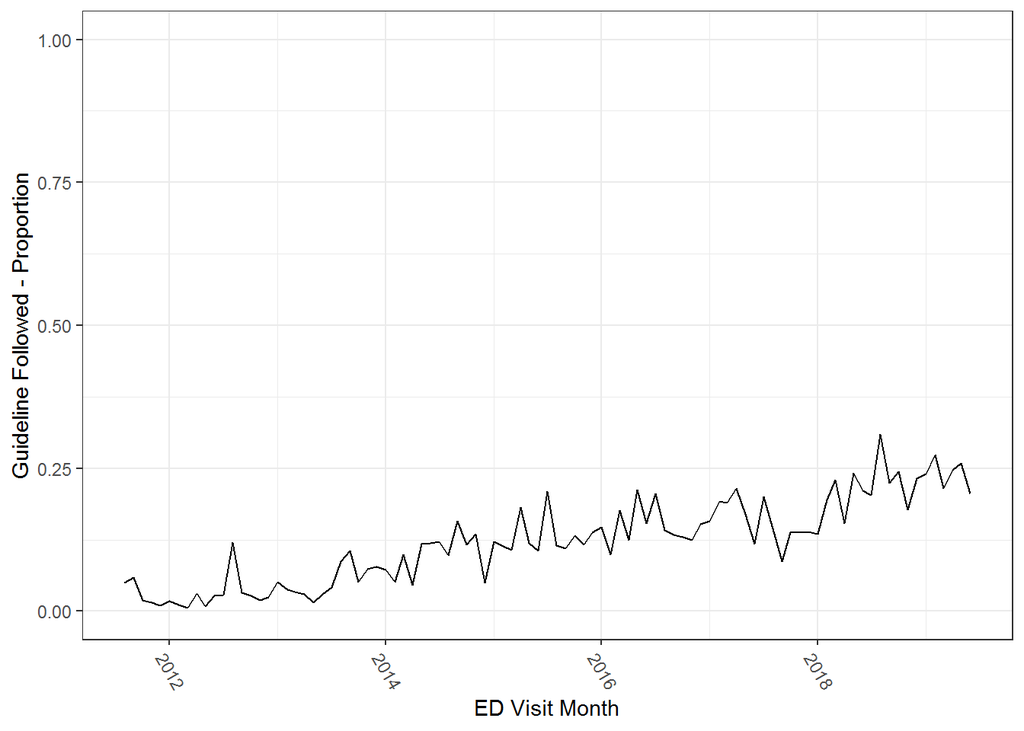

```r
# adherence over time
coh.sub %>%
  mutate(var = arr_yr_mo) %>%
  group_by(var, dur_compl) %>%
  summarise(n = n()) %>%
  mutate(sum = sum(n),
         prop = n/sum) %>%
  filter(dur_compl == 'Guideline Followed') %>%
  # mutate(var = fct_reorder(var, n, .desc = T)) %>%
  ggplot(aes(x = var, y = prop)) +
  geom_line() +
  theme(axis.text.x = element_text(angle=-60, hjust = 0.1)) +
  xlab('ED Visit Month') +
  ylab('Guideline Followed - Proportion') +
  ylim(0,1)
```

The presence of a “complex chronic condition” does not appear to influence adherence to the guidelines.

```r
tab <- coh.sub %>%
  mutate(var = MED_COMPLEX_IND) %>%
  group_by(var, dur_compl) %>%
  summarise(n = n()) %>%
  mutate(sum = sum(n),
         prop = n/sum)

# turn into a matrix
mat <- tab %>%
  select(-sum, -prop) %>%
  pivot_wider(
    names_from = dur_compl,
    values_from = n
  ) %>%
  column_to_rownames('var') %>%
  as.matrix()

# Fisher's Exact Test adherence versus CCC
fisher.test(mat)
```

```
##
##  Fisher's Exact Test for Count Data
##
## data:  mat
## p-value = 0.4029
## alternative hypothesis: true odds ratio is not equal to 1
## 95 percent confidence interval:
##  0.6158204 1.1846414
## sample estimates:
## odds ratio
##  0.8630893
```

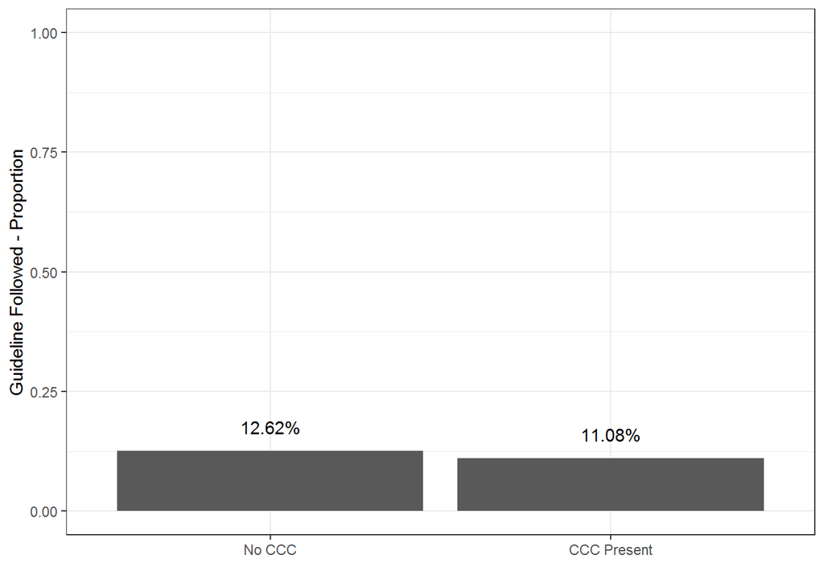

```r
tab %>%
  filter(dur_compl == 'Guideline Followed') %>%
  # arrange(desc(n)) %>%
  # ungroup() %>%
  # mutate(var = fct_reorder(var, n, .desc = T)) %>%
  ggplot(aes(x = var, y = prop)) +
  geom_col() +
  geom_text(aes(label=paste0(round(100*prop, 2),'%')), nudge_y = .05) +
  # scale_y_log10() +
  # theme(axis.text.x = element_text(angle=-60, hjust = 0.1)) +
  xlab('') +
  ylab('Guideline Followed - Proportion') +
  ylim(0,1)
```

There is some variation in adherence to the guidelines by which antibiotic was prescribed.

```r
# logistic regression for association between adherence and antibiotic
f <- glm(dur_compl ~ abx_name, family = binomial, data = coh.sub)
broom::tidy(f, exponentiate = T, conf.int = T) # the meaning of the estimate for year-mo would be difficult to interpret
```

```
## # A tibble: 4 x 7
##   term                            estimate std.error statistic p.value conf.low conf.high
##   <chr>                              <dbl>     <dbl>     <dbl>   <dbl>    <dbl>     <dbl>
## 1 (Intercept)                        0.144    0.0281   -69.0   0          0.136     0.152
## 2 abx_nameAmoxicillin Clavulanate    0.802    0.0978    -2.26  0.0240     0.659     0.968
## 3 abx_nameCefdinir                   1.39     0.118      2.81  0.00498    1.10      1.75
## 4 abx_nameClindamycin                1.22     0.314      0.644 0.519      0.629     2.18
```

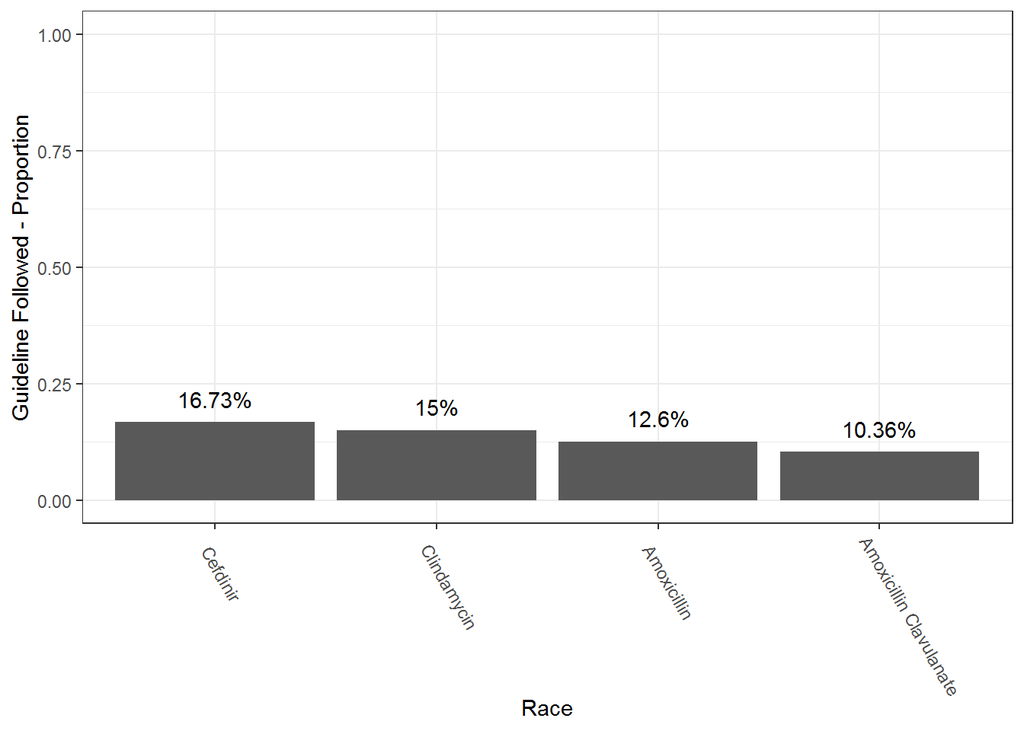

```r
coh.sub %>%
  mutate(var = abx_name) %>%
  group_by(var, dur_compl) %>%
  summarise(n = n()) %>%
  mutate(sum = sum(n),
         prop = n/sum) %>%
  filter(dur_compl == 'Guideline Followed' & !is.na(var)) %>%
  arrange(desc(n)) %>%
  ungroup() %>%
  mutate(var = fct_reorder(var, prop, .desc = T)) %>%
  ggplot(aes(x = var, y = prop)) +
  geom_col() +
  geom_text(aes(label=paste0(round(100*prop, 2),'%')), nudge_y = .05) +
  # scale_y_log10() +
  theme(axis.text.x = element_text(angle=-60, hjust = 0.1)) +
  xlab('Race') +
  ylab('Guideline Followed - Proportion') +
  ylim(0,1)
```

There is some slight variation in adherence based on day of the week.

```r
tab <- coh.sub %>%
  mutate(var = med_dow) %>%
  group_by(var, dur_compl) %>%
  summarise(n = n()) %>%
  mutate(sum = sum(n),
         prop = n/sum)


# turn into a matrix
mat <- tab %>%
  select(-sum, -prop) %>%
  pivot_wider(
    names_from = dur_compl,
    values_from = n
  ) %>%
  column_to_rownames('var') %>%
  as.matrix()

# Fisher's Exact Test
fisher.test(mat, simulate.p.value = T)
```

```
##
##  Fisher's Exact Test for Count Data with simulated p-value (based on 2000 replicates)
##
## data:  mat
## p-value = 0.04498
## alternative hypothesis: two.sided
```

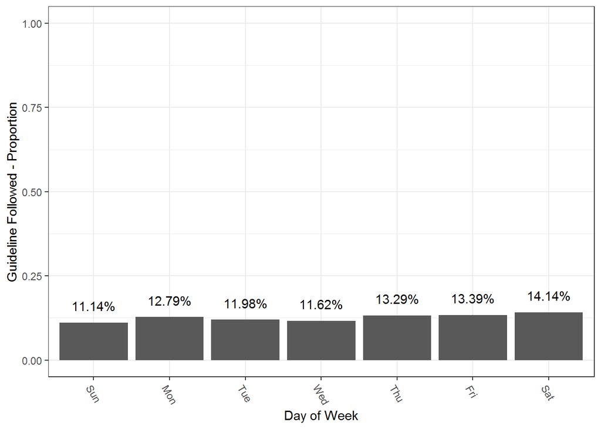

```r
 tab %>%
  filter(dur_compl == 'Guideline Followed') %>%
  # arrange(desc(n)) %>%
  # ungroup() %>%
  # mutate(var = fct_reorder(var, n, .desc = T)) %>%
  ggplot(aes(x = var, y = prop)) +
  geom_col() +
  geom_text(aes(label=paste0(round(100*prop, 2),'%')), nudge_y = .05) +
  # scale_y_log10() +
  theme(axis.text.x = element_text(angle=-60, hjust = 0.1)) +
  xlab('Day of Week') +
  ylab('Guideline Followed - Proportion') +
  ylim(0,1)
```

There is some, although questionably significant variation in adherence to the guidelines by time of day. We initially hypothesized that adherence might be worse during busier times of day as changing the prescribed duration required extra work.

```r
tab <- coh.sub %>%
  mutate(var = med_hr) %>%
  group_by(var, dur_compl) %>%
  summarise(n = n()) %>%
  mutate(sum = sum(n),
         prop = n/sum)

# turn into a matrix
mat <- tab %>%
  select(-sum, -prop) %>%
  pivot_wider(
    names_from = dur_compl,
    values_from = n
  ) %>%
  column_to_rownames('var') %>%
  as.matrix()

# Fisher's Exact Test
fisher.test(mat, simulate.p.value = T)
```

```
##
##  Fisher's Exact Test for Count Data with simulated p-value (based on 2000 replicates)
##
## data:  mat
## p-value = 0.0004998
## alternative hypothesis: two.sided
```

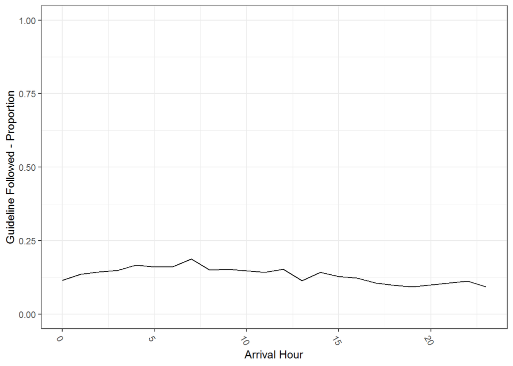

```r
tab %>%
  filter(dur_compl == 'Guideline Followed') %>%
  # arrange(desc(n)) %>%
  # ungroup() %>%
  # mutate(var = fct_reorder(var, n, .desc = T)) %>%
  ggplot(aes(x = var, y = prop)) +
  geom_line() +
  # geom_text(aes(label=paste0('n = ',n,' \n(',round(100*prop, 2),'%)')), nudge_y = .1) +
  # scale_y_log10() +
  theme(axis.text.x = element_text(angle=-60, hjust = 0.1)) +
  xlab('Arrival Hour') +
  ylab('Guideline Followed - Proportion') +
  ylim(0,1)
```

There seems to be significant variation in adherence to guidelines based on provider type, noting that medical students are quite underpresented (only 3 in the cohort).

```r
# logistic regression for association between adherence and provider type
f <- glm(dur_compl ~ prov_rx, family = binomial, data = coh.sub)
broom::tidy(f, exponentiate = T, conf.int = T)
```

```
## # A tibble: 5 x 7
##   term                   estimate std.error statistic  p.value conf.low conf.high
##   <chr>                     <dbl>     <dbl>     <dbl>    <dbl>    <dbl>     <dbl>
## 1 (Intercept)               0.127    0.0360    -57.2  0.          0.119     0.137
## 2 prov_rxFellow             3.13     0.0991     11.5  1.35e-30    2.57      3.79
## 3 prov_rxMedical Student    3.93     1.23        1.12 2.64e- 1    0.182    41.0
## 4 prov_rxNP/PA              0.743    0.0818     -3.63 2.89e- 4    0.632     0.871
## 5 prov_rxResident           1.51     0.0630      6.53 6.70e-11    1.33      1.71
```

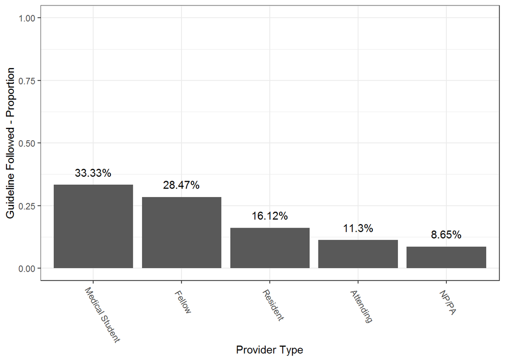

```r
coh.sub %>%
  mutate(var = prov_rx) %>%
  group_by(var, dur_compl) %>%
  summarise(n = n()) %>%
  mutate(sum = sum(n),
         prop = n/sum) %>%
  filter(dur_compl == 'Guideline Followed' & !is.na(var)) %>%
  arrange(desc(n)) %>%
  ungroup() %>%
  mutate(var = fct_reorder(var, prop, .desc = T)) %>%
  ggplot(aes(x = var, y = prop)) +
  geom_col() +
  geom_text(aes(label=paste0(round(100*prop, 2),'%')), nudge_y = .05) +
  # scale_y_log10() +
  theme(axis.text.x = element_text(angle=-60, hjust = 0.1)) +
  xlab('Provider Type') +
  ylab('Guideline Followed - Proportion') +
  ylim(0,1)
```

There was slightly better adherence to the guidelines when the Order Set was **not** used. This is perhaps not surprising since the Order Set defaulted to 10 days. Even when the Order Set was not used, adherence still was not great.

```r
tab <- coh.sub %>%
  mutate(var = ss_used_med) %>%
  group_by(var, dur_compl) %>%
  summarise(n = n()) %>%
  mutate(sum = sum(n),
         prop = n/sum)

# turn into a matrix
mat <- tab %>%
  select(-sum, -prop) %>%
  pivot_wider(
    names_from = dur_compl,
    values_from = n
  ) %>%
  column_to_rownames('var') %>%
  as.matrix()

# Fisher's Exact Test
fisher.test(mat)
```

```
##
##  Fisher's Exact Test for Count Data
##
## data:  mat
## p-value = 8.133e-07
## alternative hypothesis: true odds ratio is not equal to 1
## 95 percent confidence interval:
##  0.6206723 0.8128953
## sample estimates:
## odds ratio
##  0.7095874
```

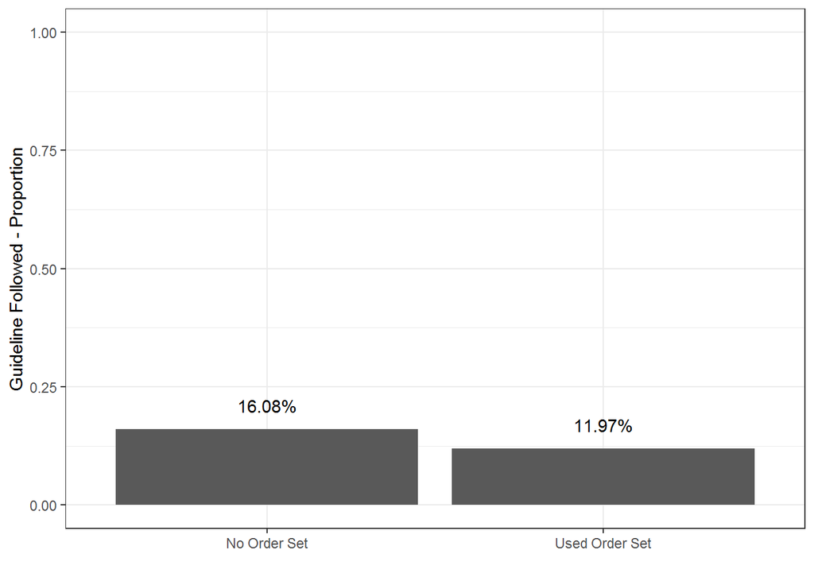

```r
tab %>%
  filter(dur_compl == 'Guideline Followed') %>%
  # arrange(desc(n)) %>%
  # ungroup() %>%
  # mutate(var = fct_reorder(var, n, .desc = T)) %>%
  ggplot(aes(x = var, y = prop)) +
  geom_col() +
  geom_text(aes(label=paste0(round(100*prop, 2),'%')), nudge_y = .05) +
  # scale_y_log10() +
  # theme(axis.text.x = element_text(angle=-60, hjust = 0.1)) +
  xlab('') +
  ylab('Guideline Followed - Proportion') +
  ylim(0,1)
```

#### Logistic Regression

With all variables summarized above included in the model, several features remained significant. As might be expected from univariable analyses above, these included:

- Year of Visit - better adherence in later (more recent) years
- Patient Age - better adherence for older patients
- Provider Type - relative to attending physicians, residents and fellows were more likely to prescribe adherent durations, while advanced-practice providers were less likely to prescribe adherent durations
- Whether the order set was used - use of the Order Set was associated with worse adherence to the guideline (possibly because of the default, longer duration)
- Time of day - late morning prescriptions were more likely to be adherent
- Day of the week - prescriptions on Friday and Saturday were more likely to be adherent (the reason for this is unclear)
- Prescriptions for Amoxicillin/Clav (Augmentin) were less likely to be adherent to the guideline

```r
coh.mod_var <-
  coh.sub %>%
  select(dur_compl, abx_name , race_f, age_yr, sex_f, MED_COMPLEX_IND, med_hr_cut, med_dow, arr_yr, ss_used_med, prov_rx) %>%
  drop_na() %>%
  mutate(race_f = factor(race_f), # to account for dropped NA
         med_dow = factor(med_dow, ordered = F) # so that it displays correctly
         )

f.full <- glm(dur_compl ~ ., family = binomial, data = coh.mod_var)
summary(f.full)
```

```
##
## Call:
## glm(formula = dur_compl ~ ., family = binomial, data = coh.mod_var)
##
## Deviance Residuals:
##     Min       1Q   Median       3Q      Max
## -1.6792  -0.5580  -0.3948  -0.2670   2.9238
##
## Coefficients:
##                                                   Estimate Std. Error z value Pr(>|z|)
## (Intercept)                                     -6.454e+02  2.683e+01 -24.054  < 2e-16 ***
## abx_nameAmoxicillin Clavulanate                 -2.725e-01  1.030e-01  -2.646  0.00815 **
## abx_nameCefdinir                                 2.293e-01  1.251e-01   1.833  0.06673 .
## abx_nameClindamycin                              2.214e-01  3.310e-01   0.669  0.50361
## race_fAsian                                      3.863e-01  1.097e+00   0.352  0.72473
## race_fBlack or African American                  1.895e-01  1.088e+00   0.174  0.86176
## race_fIndian                                     5.348e-01  1.119e+00   0.478  0.63282
## race_fMulti-racial                              -5.937e-02  1.103e+00  -0.054  0.95706
## race_fNative Hawaiian or Other Pacific Islander  1.529e+00  1.312e+00   1.166  0.24370
## race_fOther                                      5.144e-02  1.090e+00   0.047  0.96236
## race_fRefused                                    8.373e-01  1.358e+00   0.617  0.53743
## race_fWhite                                      7.842e-02  1.090e+00   0.072  0.94267
## age_yr                                           8.344e-02  7.266e-03  11.484  < 2e-16 ***
## sex_fM                                           2.829e-02  5.496e-02   0.515  0.60674
## MED_COMPLEX_INDCCC Present                      -3.516e-01  1.693e-01  -2.077  0.03780 *
## med_hr_cut[3,6)                                  1.568e-01  1.279e-01   1.226  0.22022
## med_hr_cut[6,9)                                  2.085e-01  1.272e-01   1.640  0.10105
## med_hr_cut[9,12)                                 2.797e-01  1.107e-01   2.528  0.01148 *
## med_hr_cut[12,15)                                2.124e-01  1.103e-01   1.926  0.05409 .
## med_hr_cut[15,18)                                7.162e-02  1.133e-01   0.632  0.52725
## med_hr_cut[18,21)                               -1.676e-01  1.103e-01  -1.519  0.12881
## med_hr_cut[21,24)                               -1.131e-01  1.082e-01  -1.045  0.29597
## med_dowMon                                       1.567e-01  9.970e-02   1.571  0.11609
## med_dowTue                                       1.172e-01  1.010e-01   1.160  0.24612
## med_dowWed                                       5.121e-02  1.031e-01   0.497  0.61927
## med_dowThu                                       1.821e-01  1.015e-01   1.794  0.07283 .
## med_dowFri                                       2.570e-01  1.009e-01   2.548  0.01083 *
## med_dowSat                                       2.732e-01  9.619e-02   2.841  0.00450 **
## arr_yr                                           3.188e-01  1.329e-02  23.990  < 2e-16 ***
## ss_used_medUsed Order Set                       -1.827e-01  7.351e-02  -2.485  0.01294 *
## prov_rxFellow                                    1.075e+00  1.059e-01  10.152  < 2e-16 ***
## prov_rxMedical Student                           2.098e+00  1.243e+00   1.687  0.09158 .
## prov_rxNP/PA                                    -5.972e-01  8.522e-02  -7.007 2.43e-12 ***
## prov_rxResident                                  3.118e-01  7.378e-02   4.227 2.37e-05 ***
## ---
## Signif. codes:  0 '***' 0.001 '**' 0.01 '*' 0.05 '.' 0.1 ' ' 1
##
## (Dispersion parameter for binomial family taken to be 1)
##
##     Null deviance: 10120.4  on 13383  degrees of freedom
## Residual deviance:  9068.8  on 13350  degrees of freedom
## AIC: 9136.8
##
## Number of Fisher Scoring iterations: 5
```

```r
full.sum <- broom::tidy(f.full, conf.int = T, exponentiate =T)
# full.sum

lr.full <- full.sum %>%
  select(term, OR = estimate , conf.2.5 = conf.low, conf.97.5 = conf.high, p.value) %>%
  filter(!term %in% c('(Intercept)')) %>%
  mutate_at(vars(c(OR:conf.97.5)), function(x) round(x,2)) %>%
  mutate_at(vars(p.value), function(x) round(x,3)) %>%
  mutate(p.value = ifelse(p.value < 0.001,0.001, p.value))

lr.full %>%
  arrange(p.value, OR) %>%
  filter(p.value <= 0.05)
```

```
## # A tibble: 11 x 5
##    term                               OR conf.2.5 conf.97.5 p.value
##    <chr>                           <dbl>    <dbl>     <dbl>   <dbl>
##  1 prov_rxNP/PA                     0.55     0.46      0.65   0.001
##  2 age_yr                           1.09     1.07      1.1    0.001
##  3 prov_rxResident                  1.37     1.18      1.58   0.001
##  4 arr_yr                           1.38     1.34      1.41   0.001
##  5 prov_rxFellow                    2.93     2.38      3.6    0.001
##  6 med_dowSat                       1.31     1.09      1.59   0.005
##  7 abx_nameAmoxicillin Clavulanate  0.76     0.62      0.93   0.008
##  8 med_dowFri                       1.29     1.06      1.58   0.011
##  9 med_hr_cut[9,12)                 1.32     1.07      1.64   0.011
## 10 ss_used_medUsed Order Set        0.83     0.72      0.96   0.013
## 11 MED_COMPLEX_INDCCC Present       0.7      0.5       0.97   0.038
```

Although the primary goal of this analysis was to determine factors associated with adherence to the guideline, we can also evaluate the model performance and whether it would effectively predict adherence to the guidelines. As shown in this ROC curve, the model is able ot explain some variance in the outcome, but has relatively middling performance with an AUC of ~ 0.73.

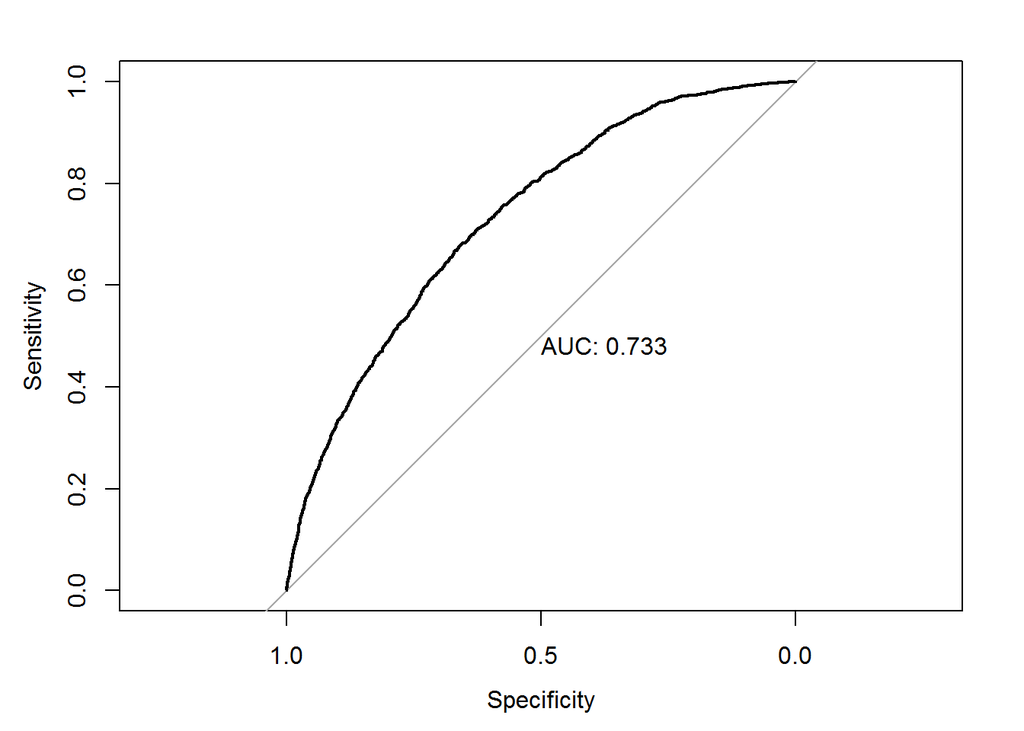

```
##
## Call:
## roc.formula(formula = coh.mod_var$dur_compl ~ predict(f.full,     type = "response"), plot = T, print.auc = T)
##
## Data: predict(f.full, type = "response") in 11702 controls (coh.mod_var$dur_compl Prolonged Duration) < 1682 cases (coh.mod_var$dur_compl Guideline Followed).
## Area under the curve: 0.7328
```

```r
library(pROC)
roc(coh.mod_var$dur_compl ~ predict(f.full, type='response'), plot=T, print.auc=T)
```

#### Proportions (p) Chart for Guideline Adherence

After reviewing this baseline data, we updated the order set used by clinicians to discharge patients with ear complaints form the ED. To assess the effectiveness of our intervention, we used a Shewart control chart known as a p- or “proportions” chart. We see that adherence to the guidelines improved following updates to the order set.

```r
# there are packages in R for control charts, but there is less control over the display, so we will create our own

# patch to deal with inconsistent names between real and sample data, and absence of day in sample data

set.seed(1234)
if (!all(c('ARR_YEAR','ARR_MO','ARR_DAY') %in% names(meds.coh.all))) {
  meds.coh.all <- meds.coh.all %>%
    rowwise() %>% # force rowwise evaluation for sampling of days
    mutate(ARR_YEAR = arr_yr,
           ARR_MO = arr_mo,
           ARR_DAY = sample(1:days_in_month(ARR_MO),1) # sample days from reasonable days for the month
           ) %>%
    ungroup()
} else {
  print('no changes made')
}
```

```
## [1] "no changes made"
```

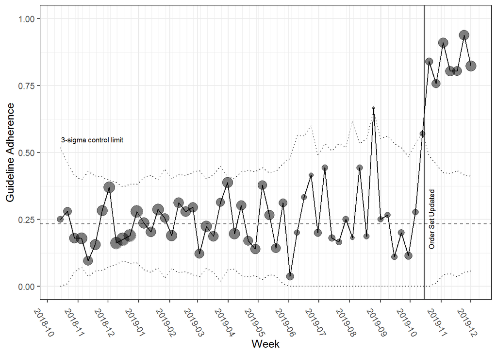

```r
# pull data for the p chart
cont.chart.data <- meds.coh.all %>% # we left this data frame unfiltered above, so it contains the most recent data
  mutate(arr_date = ymd(paste0(ARR_YEAR, str_pad(ARR_MO, 2, 'left', pad = '0'), str_pad(ARR_DAY, 2, 'left', pad = '0')))) %>%
  filter(age_yr >= 2) %>%
  filter(arr_date >= ymd('2018-10-15',tz='UTC')) %>% # we only want to look at the year prior to the intervention
  filter(abx_name != 'Azithromycin')

p.data <- cont.chart.data %>%
  mutate(time = arr_yr_wk) %>%
  group_by(time) %>%
  summarise(
    # n_ss = sum(ss_used_med == 'No Order Set'),
    n = sum(dur_compl == 'Guideline Followed'),
    total = n(),
    # prop_no_ss = n_ss/total,
    prop = n/total
  )

# calculate the center line for the p-chart
cl <- cont.chart.data %>%
  filter(arr_date <= ymd('2019-10-15',tz='UTC')) %>% # for the center line, we only want data through the date of the intervention
  mutate(time = arr_yr_wk) %>%
  group_by(time) %>%
  summarise(
    # n_ss = sum(ss_used_med == 'No Order Set'),
    n_dur = sum(dur_compl == 'Guideline Followed'),
    total = n(),
    # prop_no_ss = n_ss/total,
    prop_dur = n_dur/total
  ) %>%
  ungroup() %>%
  summarise(
    n = sum(n_dur),
    total = sum(total),
    cl = n/total
  ) %>%
  pull(cl) # extract just this variable

# calculate parameters needed for control chart
p.data <- p.data %>%
  mutate(
    sd = sqrt((cl*(1-cl))/total), # standard deviation for binomial proportion
    ucl = cl + 3*sd, # upper and lower control limits with z of 3
    lcl = cl - 3*sd,
    ucl = ifelse(ucl > 1, 1, ucl),
    lcl = ifelse(lcl < 0, 0, lcl)
  )

p.data %>%
  ggplot(aes(x=time, y=prop)) +
  geom_line() +
  geom_point(aes(x=time, y=prop, size = total), alpha = 0.5) + # points on chart - size proportional to n per group
  # geom_errorbar(aes(ymin = lcl , ymax = ucl)) +
  geom_line(aes(y=lcl), linetype = 3, color = 'black', alpha = 0.75) +
  geom_line(aes(y=ucl), linetype = 3, color = 'black', alpha = 0.75) +
  geom_hline(yintercept = cl, linetype = 2, color = 'black', alpha = 0.5) +
  geom_vline(aes(xintercept=ymd('2019-10-15',tz='UTC'))) +
  annotate('text',x=ymd('2019-10-22',tz='UTC'),y=0.25,angle=90,label='Order Set Updated', size = 2.5) +
  annotate('text',x=ymd('2018-11-15',tz='UTC'),y=0.55,label='3-sigma control limit', size = 2.5) +
  ylim(0,1) +
  scale_x_datetime(date_minor_breaks = '1 week', date_breaks = '1 month', date_labels = '%Y-%m') +
  xlab('Week') +
  ylab('Guideline Adherence') +
  # ggtitle('Adherence to AOM Guidelines Over Time (age >= 2 years)') +
  theme(axis.text.x = element_text(angle = -60), legend.position = 'none') +
  scale_size('')
```

### Prediction Model for Antibiotic Choice

Although not a primary outcome, we were interested in whether the chosen covariates could be used to predict which antibiotic would be prescribed. We used several machine learning models to explore this - penalized multinomial regression, naive Bayes, random forest, and eXtreme gradient boosting (xgboost).

There is significant class imbalance in the outcome variable (antibiotic) as amoxicillin is by far the most commonly prescribed. To deal with this, we will use resampling methods so that the models don’t just predict the over-represented class (amoxicillin).

```r
# choose most common antibiotics - here we can include azithromycin since duration is not important for this classifier
meds.coh %>%
  group_by(abx_name) %>%
  summarise(n = n()) %>%
  arrange(desc(n))
```

```
## # A tibble: 16 x 2
##    abx_name                          n
##    <fct>                         <int>
##  1 Amoxicillin                   22416
##  2 Amoxicillin Clavulanate        3006
##  3 Cefdinir                       1040
##  4 Azithromycin                    441
##  5 Clindamycin                     145
##  6 Cephalexin                       29
##  7 Cefuroxime                       26
##  8 Sulfamethoxazole Trimethoprim    12
##  9 Cefixime                         10
## 10 Ciprofloxacin                    10
## 11 Levofloxacin                      8
## 12 Cefprozil                         6
## 13 Cefpodoxime                       2
## 14 Ceftriaxone                       2
## 15 Erythromycin                      1
## 16 Penicillin V                      1
```

```r
top.meds <- meds.coh %>%
  group_by(abx_name) %>%
  summarise(n = n()) %>%
  arrange(desc(n)) %>%
  filter(n > 150) %>%
  pull(abx_name)

# patch so multiclass roc curves work for sample data
if (nrow(cohort) <= 5000) {
  top.meds <- c('Amoxicillin','Amoxicillin Clavulanate','Cefdinir','Azithromycin')
}

# select covariates of interest
abx.coh <- meds.coh %>%
  filter(abx_name %in% top.meds) %>%
  select(abx_name , race_f, age_yr, sex_f, MED_COMPLEX_IND, arr_yr, ss_used_med, prov_rx, pcn_all, azith_all, cef_all) %>%
  drop_na() %>%
  mutate(race_f = factor(race_f), # to account for dropped NA
         abx_name = factor(abx_name) # account for dropped names
         )
```

Briefly summarise relationship between antibiotic choice and covariates. Not many of the covariates appear to be correlated with antibiotic choice. As might be expected, the presence of allergies seems to be related to antibiotic choice.

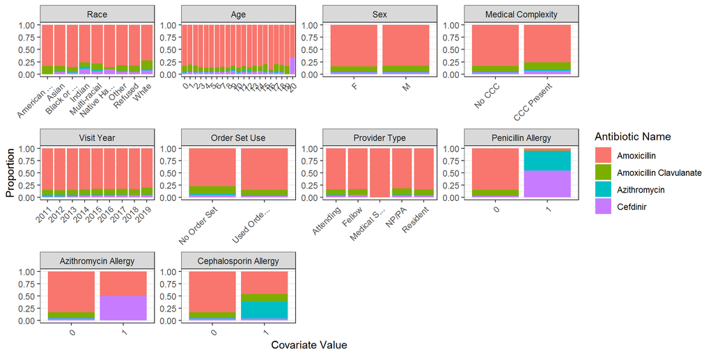

```r
#figure width in inches

var_names <- abx.coh %>%
  mutate_if(is.double, factor) %>%
  pivot_longer(cols = race_f:cef_all,
               values_to = 'vals') %>%
  pull(name) %>%
  unique()

# used to make nicer labels for variables in facetes
var_labels <- c('Race',
                'Age',
                'Sex',
                'Medical Complexity',
                'Visit Year',
                'Order Set Use',
                'Provider Type',
                'Penicillin Allergy',
                'Azithromycin Allergy',
                'Cephalosporin Allergy')

abx.coh %>%
  mutate_if(is.double, factor) %>%
  pivot_longer(cols = race_f:cef_all,
               values_to = 'vals') %>%
  mutate(name = factor(name, levels=var_names, labels = var_labels)) %>%
  # group_by(name) %>%
  # mutate(n_name = n()) %>%
  group_by(name, vals) %>%
  mutate(n_val = n()) %>%
  group_by(name, vals, abx_name) %>%
  mutate(n_abx = n()) %>%
  mutate(
    prop = n_abx/n_val
  ) %>%
  distinct() %>%
  arrange(name, vals, abx_name) %>%
  ggplot(aes(x=vals, y=prop, fill=abx_name)) +
  geom_col() +
  scale_x_discrete(label = function(x) stringr::str_trunc(x, 12)) + #shorten x-axis labels
  scale_fill_discrete('Antibiotic Name') +
  facet_wrap(~ name, scales = 'free') +
  xlab('Covariate Value') +
  ylab('Proportion') +
  theme(axis.text.x = element_text(angle = 45, hjust = 1))
```

#### Training and Test Samples

```r
# create dummy variables for multi-level factors - essentially 1-hot vectors for categories
dummies <- dummyVars(abx_name ~ ., data=abx.coh)

dummies <- as_tibble(predict(dummies, abx.coh))

abx.coh <- cbind(abx_name = abx.coh$abx_name, dummies)

# use caret package to split data into test and training sets (70%/30%)
set.seed(54321)
idxtrain <- createDataPartition(y = abx.coh$abx_name, p = 0.7, list =F)
train <- abx.coh[idxtrain,]
testing <- abx.coh[-idxtrain,]

train.resamp <- UBL::SmoteClassif(abx_name ~ ., dat = train, C.perc = "balance", dist = "HEOM")
# balance results in balancing classes of antibiotics
# HEOM allwos for both numeric and nominal values in data (default is Euclidian)

# scale and center continuous variables
pp <- preProcess(train.resamp %>% select(age_yr, arr_yr), c('scale','center','nzv'))

transformed <- predict(pp, newdata = train.resamp)

# scale and center continuous variables
trans.test <- predict(pp, newdata = testing)
```

```r
# fit multinomial logistic regression model

f.mn <- multinom(abx_name ~ ., data = train)
# summary(f.mn)

(confusionMatrix(predict(f.mn, testing), testing$abx_name))
```

```
## Confusion Matrix and Statistics
##
##                          Reference
## Prediction                Amoxicillin Amoxicillin Clavulanate Azithromycin Cefdinir
##   Amoxicillin                    6715                     900          100      256
##   Amoxicillin Clavulanate           0                       0            0        0
##   Azithromycin                      7                       1           22       11
##   Cefdinir                          2                       0           10       45
##
## Overall Statistics
##
##                Accuracy : 0.8405
##                  95% CI : (0.8323, 0.8484)
##     No Information Rate : 0.8333
##     P-Value [Acc > NIR] : 0.04234
##
##                   Kappa : 0.0961
##
##  Mcnemar's Test P-Value : NA
##
## Statistics by Class:
##
##                      Class: Amoxicillin Class: Amoxicillin Clavulanate Class: Azithromycin Class: Cefdinir
## Sensitivity                     0.99866                         0.0000            0.166667        0.144231
## Specificity                     0.06617                         1.0000            0.997606        0.998453
## Pos Pred Value                  0.84243                            NaN            0.536585        0.789474
## Neg Pred Value                  0.90816                         0.8883            0.986298        0.966675
## Prevalence                      0.83331                         0.1117            0.016359        0.038667
## Detection Rate                  0.83220                         0.0000            0.002726        0.005577
## Detection Prevalence            0.98785                         0.0000            0.005081        0.007064
## Balanced Accuracy               0.53242                         0.5000            0.582136        0.571342
```

```r
# Initiate multicore processing to decrease time required to fit models - particularly RF
(cores <- floor(0.9*(parallel::detectCores())))
```

```
## [1] 28
```

```r
cl <- makeCluster(cores) #use 90% of cores
# str(cl)
registerDoParallel(cl)
```

Here we define parameters that control model training and resampling.

```r
tr_control <- trainControl(## 10-fold CV
                           method = "cv",
                           number = 10,
                           verboseIter = T)
```

#### Penalized Multinomial Regression

```r
# set seed as random samples are used for cross-validation
set.seed(1234)

# fit model
system.time(
pmr.abx <- train(
            abx_name ~ .,
            data = transformed,
            method = "multinom",
            trControl = tr_control,
            tuneLength = 10, # fit using 10 different values of hyper-parameter
            metric = 'Kappa' # optimize to Kapp (as opposed to accuracy)
            )
)
```

```
##    user  system elapsed
##    9.22    2.11  166.60
```

```r
# show confusion matrix for penalized multinomial regression
(pmr.test <- confusionMatrix(predict(pmr.abx, trans.test), testing$abx_name))
```

```
## Confusion Matrix and Statistics
##
##                          Reference
## Prediction                Amoxicillin Amoxicillin Clavulanate Azithromycin Cefdinir
##   Amoxicillin                    2734                     264           23       79
##   Amoxicillin Clavulanate        1651                     301           20       80
##   Azithromycin                   1432                     169           76       59
##   Cefdinir                        907                     167           13       94
##
## Overall Statistics
##
##                Accuracy : 0.3972
##                  95% CI : (0.3865, 0.408)
##     No Information Rate : 0.8333
##     P-Value [Acc > NIR] : 1
##
##                   Kappa : 0.0615
##
##  Mcnemar's Test P-Value : <2e-16
##
## Statistics by Class:
##
##                      Class: Amoxicillin Class: Amoxicillin Clavulanate Class: Azithromycin Class: Cefdinir
## Sensitivity                      0.4066                         0.3341            0.575758         0.30128
## Specificity                      0.7279                         0.7557            0.790853         0.85987
## Pos Pred Value                   0.8819                         0.1467            0.043779         0.07959
## Neg Pred Value                   0.1970                         0.9003            0.991157         0.96835
## Prevalence                       0.8333                         0.1117            0.016359         0.03867
## Detection Rate                   0.3388                         0.0373            0.009419         0.01165
## Detection Prevalence             0.3842                         0.2543            0.215144         0.14636
## Balanced Accuracy                0.5672                         0.5449            0.683305         0.58058
```

#### Naive Bayes

```r
# Grid of model parameters for optimizing fit
tunegrid <- expand.grid(
  usekernel = c(TRUE, FALSE),
  laplace = 0:3,
  adjust = c(0,0.5,1,2,3)
)

# seed for random sampling in CV
set.seed(1234)

# Fit naive bayes model
system.time(
nb.abx <- train(
            abx_name ~ .,
            data = transformed,
            method = "naive_bayes",
            trControl = tr_control,
            metric = 'Kappa',
            tuneGrid = tunegrid
            )
)
```

```
##    user  system elapsed
##    3.32    2.04   10.31
```

```r
# show confusion matrix for naive bayes for test data
(nb.test <- confusionMatrix(predict(nb.abx, trans.test), testing$abx_name))
```

```
## Confusion Matrix and Statistics
##
##                          Reference
## Prediction                Amoxicillin Amoxicillin Clavulanate Azithromycin Cefdinir
##   Amoxicillin                    6724                     901          132      312
##   Amoxicillin Clavulanate           0                       0            0        0
##   Azithromycin                      0                       0            0        0
##   Cefdinir                          0                       0            0        0
##
## Overall Statistics
##
##                Accuracy : 0.8333
##                  95% CI : (0.825, 0.8414)
##     No Information Rate : 0.8333
##     P-Value [Acc > NIR] : 0.5073
##
##                   Kappa : 0
##
##  Mcnemar's Test P-Value : NA
##
## Statistics by Class:
##
##                      Class: Amoxicillin Class: Amoxicillin Clavulanate Class: Azithromycin Class: Cefdinir
## Sensitivity                      1.0000                         0.0000             0.00000         0.00000
## Specificity                      0.0000                         1.0000             1.00000         1.00000
## Pos Pred Value                   0.8333                            NaN                 NaN             NaN
## Neg Pred Value                      NaN                         0.8883             0.98364         0.96133
## Prevalence                       0.8333                         0.1117             0.01636         0.03867
## Detection Rate                   0.8333                         0.0000             0.00000         0.00000
## Detection Prevalence             1.0000                         0.0000             0.00000         0.00000
## Balanced Accuracy                0.5000                         0.5000             0.50000         0.50000
```

#### Random Forest

```r
# set seed for random forest
set.seed(1234)

# tuning model parameters
tunegrid <- expand.grid(.mtry = c(3,6,9)) # use these options for model hyper-parameter

# fit random forest
system.time(
rf.abx <- train(
            abx_name ~ .,
            data = transformed,
            method = "rf",
            trControl = tr_control,
            ntree = 500, # number of trees
            metric = 'Kappa',
            tuneGrid = tunegrid
            )
)
```

```
##    user  system elapsed
##   70.03    2.74  183.22
```

```r
# demonstrate which variables had the highest "importance" in random forest model
varImp(rf.abx)
```

```
## rf variable importance
##
##   only 20 most important variables shown (out of 25)
##
##                                    Overall
## arr_yr                             100.000
## age_yr                              86.818
## pcn_all                             38.621
## prov_rx.Attending                   11.570
## `race_f.Black or African American`  10.812
## sex_f.M                              9.740
## sex_f.F                              9.657
## prov_rx.Resident                     9.013
## `ss_used_med.No Order Set`           8.705
## `ss_used_med.Used Order Set`         8.673
## `prov_rx.NP/PA`                      8.237
## race_f.White                         7.989
## race_f.Other                         6.826
## prov_rx.Fellow                       5.703
## race_f.Asian                         4.562
## `MED_COMPLEX_IND.CCC Present`        4.352
## `race_f.Multi-racial`                4.311
## `MED_COMPLEX_IND.No CCC`             4.246
## cef_all                              2.999
## race_f.Indian                        1.837
```

```r
# confusion matrix for random forest model
(rf.test <- confusionMatrix(predict(rf.abx, trans.test), testing$abx_name))
```

```
## Confusion Matrix and Statistics
##
##                          Reference
## Prediction                Amoxicillin Amoxicillin Clavulanate Azithromycin Cefdinir
##   Amoxicillin                    4048                     459           62      137
##   Amoxicillin Clavulanate        1931                     352           26       90
##   Azithromycin                    368                      36           30       24
##   Cefdinir                        377                      54           14       61
##
## Overall Statistics
##
##                Accuracy : 0.5566
##                  95% CI : (0.5457, 0.5675)
##     No Information Rate : 0.8333
##     P-Value [Acc > NIR] : 1
##
##                   Kappa : 0.0713
##
##  Mcnemar's Test P-Value : <2e-16
##
## Statistics by Class:
##
##                      Class: Amoxicillin Class: Amoxicillin Clavulanate Class: Azithromycin Class: Cefdinir
## Sensitivity                      0.6020                        0.39068            0.227273         0.19551
## Specificity                      0.5108                        0.71443            0.946075         0.94263
## Pos Pred Value                   0.8602                        0.14673            0.065502         0.12055
## Neg Pred Value                   0.2043                        0.90317            0.986598         0.96681
## Prevalence                       0.8333                        0.11166            0.016359         0.03867
## Detection Rate                   0.5017                        0.04362            0.003718         0.00756
## Detection Prevalence             0.5832                        0.29731            0.056760         0.06271
## Balanced Accuracy                0.5564                        0.55255            0.586674         0.56907
```

```r
tunegrid <-  expand.grid(
                eta = 0.1,
                colsample_bytree=c(0.3,0.8,1),
                max_depth=c(3,6),
                nrounds=100,
                gamma=1,
                min_child_weight=1,
                subsample = c(0.8, 1)
              )

# one approach to tuning - https://towardsdatascience.com/fine-tuning-xgboost-in-python-like-a-boss-b4543ed8b1e

set.seed(1234)


system.time(
xg.abx <- train(
            abx_name ~ .,
            data = transformed,
            method = "xgbTree",
            trControl = tr_control,
            metric = 'Kappa',
            tuneGrid = tunegrid
            )
)
```

```
## Fitting nrounds = 100, max_depth = 6, eta = 0.1, gamma = 1, colsample_bytree = 0.8, min_child_weight = 1, subsample = 0.8 on full training set
```

```
##    user  system elapsed
##   62.25   19.55  282.33
```

```r
# varImp(xg.abx)

(xg.test <- confusionMatrix(predict(xg.abx, trans.test), testing$abx_name))
```

```
## Confusion Matrix and Statistics
##
##                          Reference
## Prediction                Amoxicillin Amoxicillin Clavulanate Azithromycin Cefdinir
##   Amoxicillin                    4955                     552           79      154
##   Amoxicillin Clavulanate        1556                     319           20       96
##   Azithromycin                    110                      13           22       13
##   Cefdinir                        103                      17           11       49
##
## Overall Statistics
##
##                Accuracy : 0.6624
##                  95% CI : (0.652, 0.6727)
##     No Information Rate : 0.8333
##     P-Value [Acc > NIR] : 1
##
##                   Kappa : 0.108
##
##  Mcnemar's Test P-Value : <2e-16
##
## Statistics by Class:
##
##                      Class: Amoxicillin Class: Amoxicillin Clavulanate Class: Azithromycin Class: Cefdinir
## Sensitivity                      0.7369                        0.35405            0.166667        0.157051
## Specificity                      0.4164                        0.76674            0.982865        0.983112
## Pos Pred Value                   0.8632                        0.16022            0.139241        0.272222
## Neg Pred Value                   0.2404                        0.90424            0.986095        0.966662
## Prevalence                       0.8333                        0.11166            0.016359        0.038667
## Detection Rate                   0.6141                        0.03953            0.002726        0.006073
## Detection Prevalence             0.7114                        0.24675            0.019581        0.022308
## Balanced Accuracy                0.5766                        0.56040            0.574766        0.570082
```

```r
# Compare accuracy and Kappa for training data
# resamps <- resamples(list(PMR = pmr.abx,
#                           NB = nb.abx,
#                           RF = rf.abx))
#
# summary(resamps)

# Accuracy and Kappa for Test data

bind_cols(
pmr = pmr.test$overall[c('Accuracy','Kappa')],
nb = nb.test$overall[c('Accuracy','Kappa')],
rf = rf.test$overall[c('Accuracy','Kappa')],
xg = xg.test$overall[c('Accuracy','Kappa')]
) %>%
  mutate(Parameter = c('Accuracy','Kappa')) %>%
  select(Parameter, everything())
```

```
## # A tibble: 2 x 5
##   Parameter    pmr    nb     rf    xg
##   <chr>      <dbl> <dbl>  <dbl> <dbl>
## 1 Accuracy  0.397  0.833 0.557  0.662
## 2 Kappa     0.0615 0     0.0713 0.108
```

Kappa is highest for the model using extreme gradient boosting. While accuracy is highest for the Naive Bayes model, we see that this model just predicts the majority class (amoxicillin) for every observation.

```r
# Release multicore cluster.

stopCluster(cl)
rm(cl)
```

#### Multiclass ROC and PR Curves for ML Models (Test Data)

```r
# Prep Names for multiroc
prefix <- c('amox','aug','azi','cef')

roc_true <- sapply(prefix,function(x) paste0(x,'_true'))
roc_pred <- sapply(prefix,function(x) paste0(x,'_pred'))
roc_pmr <- sapply(roc_pred,function(x) paste0(x,'_pmr'))
roc_nb <- sapply(roc_pred,function(x) paste0(x,'_nb'))
roc_rf <- sapply(roc_pred,function(x) paste0(x,'_rf'))
roc_xg <- sapply(roc_pred,function(x) paste0(x,'_xg'))


roc_names <- c(roc_pred, roc_pmr, roc_nb, roc_rf, roc_xg)
names(roc_names) <- NULL
# roc_names

# Transform abx vector into one-hot vectors
tmp <- caret::dummyVars('~ abx_name', data=trans.test)
abx_hot <- as_tibble(predict(tmp,trans.test))
names(abx_hot) <- roc_true
# str(abx_hot)

# extract probablities for each class for each method using testing data
pmr_pred <- predict(pmr.abx,trans.test,type = 'prob')
nb_pred <- predict(nb.abx,trans.test,type = 'prob')
rf_pred <- predict(rf.abx,trans.test,type = 'prob')
xg_pred <- predict(xg.abx,trans.test,type = 'prob')


names(pmr_pred) <- roc_pmr
names(nb_pred) <- roc_nb
names(rf_pred) <- roc_rf
names(xg_pred) <- roc_xg


# combine data into format expected for multiROC
mroc_data <- cbind(abx_hot, pmr_pred, nb_pred, rf_pred, xg_pred)

# get ROC and Precision-recall data for testing data
mroc_out <- multiROC::multi_roc(mroc_data) #ROC data
pr_out <- multiROC::multi_pr(mroc_data) #precision-recall data


roc_res <- multiROC::plot_roc_data(mroc_out)
pr_res <- multiROC::plot_pr_data(pr_out)
```

##### ROC AUC Values

Here, we summarise AUC values (test data) by model and type.

```r
# make nicer labels
roc_res <- roc_res %>%
  mutate(
    Group = factor(Group,levels = c('amox','aug','azi','cef','Micro','Macro'), labels=c('Amoxicillin','Amox/Clav','Azithromycin','Cefdinir','Micro','Macro')),
    Method = factor(Method, levels = c('pmr','nb','rf','xg'), labels = c('Penalized Multinomial','Naive Bayes','Random Forest','eXtreme Gradient Boosting'))
  )
```

```r
# AUC Values
roc_res %>%
  select(Group, Method, AUC) %>%
  distinct() %>%
  pivot_wider(
              names_from = Method,
              values_from = AUC)
```

```
## # A tibble: 6 x 5
##   Group        `Penalized Multinomial` `Naive Bayes` `Random Forest` `eXtreme Gradient Boosting`
##   <fct>                          <dbl>         <dbl>           <dbl>                       <dbl>
## 1 Amoxicillin                    0.635         0.606           0.593                       0.613
## 2 Amox/Clav                      0.581         0.618           0.583                       0.602
## 3 Azithromycin                   0.737         0.755           0.753                       0.741
## 4 Cefdinir                       0.668         0.708           0.641                       0.656
## 5 Macro                          0.655         0.672           0.642                       0.653
## 6 Micro                          0.704         0.934           0.829                       0.887
```

##### ROC Curves

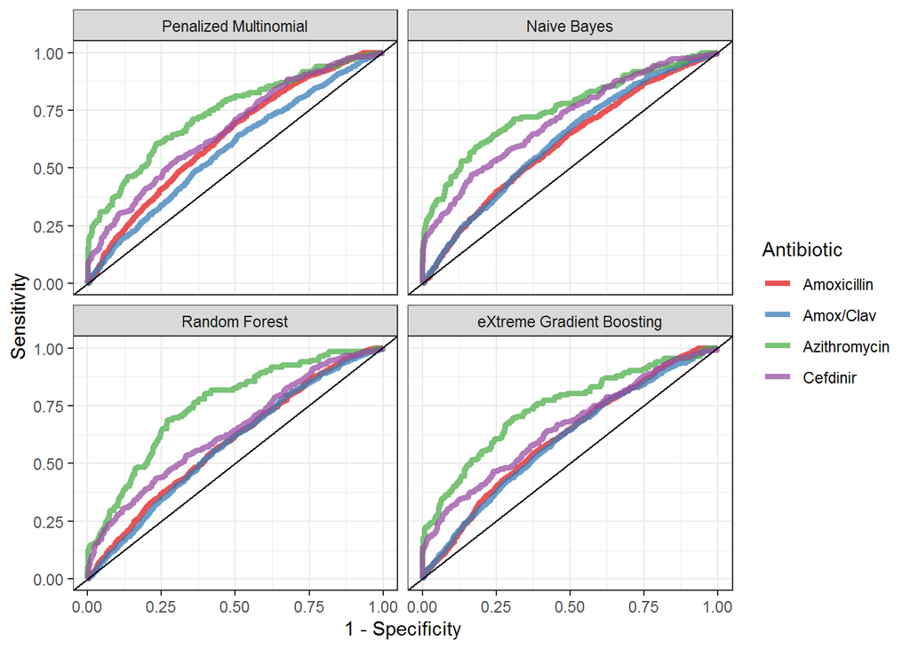

```r
# plot ROC curves for each class
roc_res %>%
  filter(!Group %in% c('Micro','Macro')) %>%
  ggplot() +
  geom_line(aes(y = Sensitivity, x = 1-Specificity, color = Group), alpha = 0.75, size = 1.5) +
  geom_abline() +
  facet_wrap(~ Method,ncol = 2) +
  scale_color_brewer('Antibiotic', type = 'qual', palette = 'Set1')
```

None of the ROC curves look particularly good for any of the models. The performance based on AUC and ROC seems to be best for azithromycin.

##### Precision-Recall AUCs

```r
# make nicer labels
pr_res <- pr_res %>%
  mutate(
    Group = factor(Group,levels = c('amox','aug','azi','cef','Micro','Macro'), labels=c('Amoxicillin','Amox/Clav','Azithromycin','Cefdinir','Micro','Macro')),
    Method = factor(Method, levels = c('pmr','nb','rf','xg'), labels = c('Penalized Multinomial','Naive Bayes','Random Forest','eXtreme Gradient Boosting'))
  )
```

```r
pr_res %>%
  select(AUC, Group, Method) %>%
  distinct() %>%
  pivot_wider(names_from = Method, values_from = AUC)
```

```
## # A tibble: 6 x 5
##   Group        `Penalized Multinomial` `Naive Bayes` `Random Forest` `eXtreme Gradient Boosting`
##   <fct>                          <dbl>         <dbl>           <dbl>                       <dbl>
## 1 Amoxicillin                    0.883         0.874           0.870                       0.877
## 2 Amox/Clav                      0.145         0.156           0.138                       0.154
## 3 Azithromycin                   0.127         0.186           0.139                       0.161
## 4 Cefdinir                       0.146         0.201           0.103                       0.192
## 5 Macro                          0.325         0.354           0.312                       0.346
## 6 Micro                          0.373         0.824           0.574                       0.705
```

##### Precision-Recall Curves

Next, we plot precision-recall curves for these models.

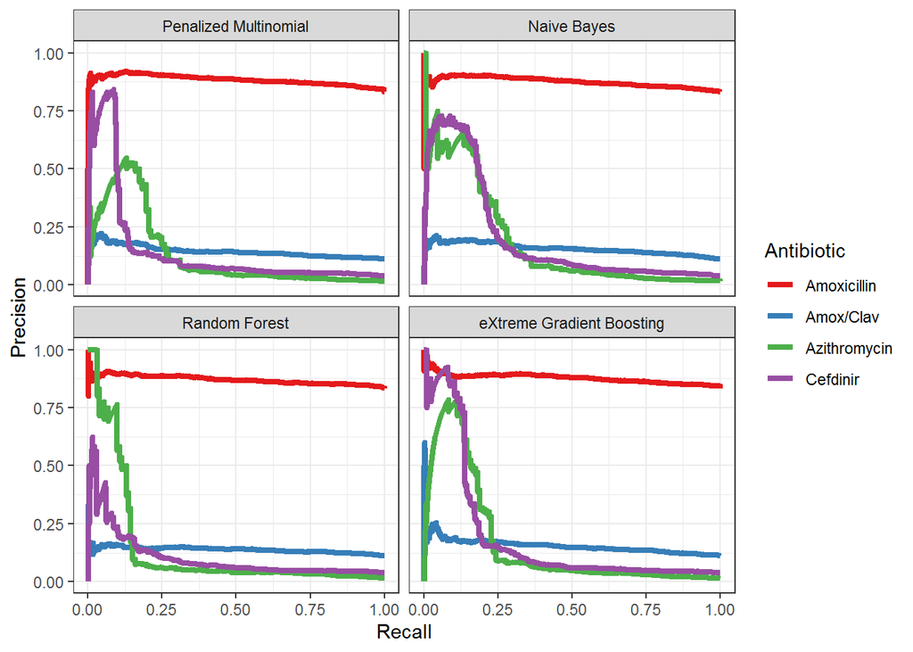

```r
# plot PR curves for each class
pr_res %>%
  filter(!Group %in% c('Micro','Macro')) %>%
  ggplot() +
  geom_line(aes(y = Precision, x = Recall, color = Group), size = 1.5) +
  facet_wrap(~ Method, ncol =2) +
  scale_color_brewer('Antibiotic', type = 'qual', palette = 'Set1')
```

In interpretation of the PR curves, it is important to note that Precision (aka PPV) for an unskilled learner will be directly proportional to the proportion of the specific class. As a result, it is not surprising that amoxicillin appears to have the best precision. For the other classes, we see that as Recall (aka sensitivity) improves, the Precision quickly drops off because we are trading better sensitivity for worse specificity (more false positives). None of the models are particularly good, but extreme gradient boosting achieved the best kappa.

#### Discussion of Classification Models

Initially, models were trained on unbalanced training data. Accuracies of 80%+ were obtained, but essentially the models always predicted the majority class (amoxicillin). To address this, we took two appraoches: 1) we used sampling methods (SMOTE) to improve class balance and 2) hyper-parameter selection was based on kappa rather than accuracy. SMOTE resulted in better results than pure downsampling. Upsampling was too inefficient to tune hyper-parameters and did not result in significant-enough improvements to justify the addditional time spent training models. Overall, despite attempts at optimization, model performance remained relatively poor for antibiotic class-prediction. Clinically, it would potentially be nearly as useful to predict patients which were prescribed any antibiotic other than amoxicillin (resulting in a binary classification). In this case, we might be better able to address the problem with class-imbalance. Alternatively, we could consider whether there are additional features that me helpful. Although there are many, they might include specific co-morbidities (immunodeficiency, chronic serous otitis, history of ear tubes) or recent visits to the ED or primary care provider (as an indicator or previously failed treatment).

### Conclusions

One of the more challenging aspects of this project was extracting prescribed duration from the prescription “SIG.” Fortunately, there were relatively consistent patterns that could be leveraged to obtain this data. In cases where this could not be extracted from the SIG, we estimated the duration from the prescribed volume.

Several features (noted above) were found to be associated with adherence to the recommended guidelines. Most importantly given our intent to best target clinical decision support, was the fact that most providers used an Order Set to order antibiotics. Similarly, the association with age was important, both with respect to different guidelines by age and the fact that older patients were likely to receive shorter durations. If our change to the CDS system is not effective, we might need to evaluate the differential adherence between provider types.

As noted above, we attempted to predict which antibiotic a patient was likely to be prescibred. We had limited success in doing so based on currently available features (covariates). To improve these models, additional features will likely be required.